# team.Rmd

Mike Brown and Nathan Marquardt

3/4/2021

1.Find the average years of education of he respondents with each marital status. Arrange your output in a meaningful order and print. Describe any patterns you find.

Answer:

```r
#install.packages('readxl')
library(dplyr)
```

```r
library(ggplot2)
dat <- readxl::read_xls('/Users/nathanmarquardt/Desktop/ds202_lab3/GSS.xls')
names(dat)
```

```
##  [1] "Gss year for this respondent"
##  [2] "General happiness"
##  [3] "Political party affiliation"
##  [4] "Total family income"
##  [5] "Respondents sex"
##  [6] "Highest year of school completed"
##  [7] "Spouse self-emp. or works for somebody"
##  [8] "No. of hrs spouse usually works a week"
##  [9] "Number of hrs spouse worked last week"
## [10] "Spouse labor force status"
## [11] "Ever been divorced or separated"
## [12] "Marital status"
## [13] "R self-emp or works for somebody"
## [14] "Number of hours usually work a week"
## [15] "Number of hours worked last week"
## [16] "Labor force status"
## [17] "Respondent id number"
## [18] "Ballot used for interview"
```

```r
dat <- rename(dat, Year = `Gss year for this respondent`)
dat <- rename(dat, Happiness = `General happiness`)
dat <- rename(dat, Politic_Party = `Political party affiliation`)
dat <- rename(dat, FamIncome = `Total family income` )
dat <- rename(dat, Sex = `Respondents sex`)
dat <- rename(dat, School_Years = `Highest year of school completed`)
dat <- rename(dat, Spouse_EmpType = `Spouse self-emp. or works for somebody`)
dat <- rename(dat, Spouse_AvgHours = `No. of hrs spouse usually works a week`)
dat <- rename(dat, Spouse_LWHours = `Number of hrs spouse worked last week`)
dat <- rename(dat, Spouse_LaborStatus = `Spouse labor force status`)
dat <- rename(dat, Div_Sep_Status = `Ever been divorced or separated`)
dat <- rename(dat, Marital_Status = `Marital status`)
dat <- rename(dat, R_EmpType = `R self-emp or works for somebody`)
dat <- rename(dat, R_AvgHours = `Number of hours usually work a week`)
dat <- rename(dat, R_LWHours = `Number of hours worked last week`)
dat <- rename(dat, R_LaborStatus = `Labor force status`)
dat <- rename(dat, R_ID = `Respondent id number`)
dat <- rename(dat, Ballot_Type = `Ballot used for interview`)

unique(dat$Year)
```

```
##  [1] 1972 1973 1974 1975 1976 1977 1978 1980 1982 1983 1984 1985 1986 1987 1988
## [16] 1989 1990 1991 1993 1994 1996 1998 2000 2002 2004 2006 2008 2010 2012 2014
## [31] 2016 2018   NA
```

```r
dat <- filter(dat, Year != "NA")

unique(dat$Happiness)
```

```
## [1] "Not too happy"  "Pretty happy"   "Very happy"     "No answer"
## [5] "Don't know"     "Not applicable"
```

```r
dat <- filter(dat, Happiness != "No answer")
dat <- filter(dat, Happiness != "Don't know")
dat <- filter(dat, Happiness != "Not applicable")

unique(dat$Politic_Party)
```

```
##  [1] "Ind,near dem"       "Not str democrat"   "Independent"
##  [4] "Strong democrat"    "Not str republican" "Ind,near rep"
##  [7] "Strong republican"  "Other party"        "No answer"
## [10] "Don't know"
```

```r
dat <- filter(dat, Politic_Party != "No answer")
dat <- filter(dat, Politic_Party != "Don't know")

unique(dat$FamIncome)
```

```
##  [1] "Not applicable" "$10000 - 14999" "$7000 to 7999"  "$4000 to 4999"
##  [5] "$1000 to 2999"  "$15000 - 19999" "$5000 to 5999"  "$20000 - 24999"
##  [9] "$3000 to 3999"  "Don't know"     "Lt $1000"       "$8000 to 9999"
## [13] "$25000 or more" "$6000 to 6999"  "Refused"        "No answer"
```

```r
dat <- filter(dat, FamIncome != "No answer")
dat <- filter(dat, FamIncome != "Not applicable")
dat <- filter(dat, FamIncome != "Don't know")
dat <- filter(dat, FamIncome != "Refused")

unique(dat$Sex)
```

```
## [1] "Male"   "Female"
```

```r
unique(dat$School_Years)
```

```
##  [1] "6"          "8"          "11"         "12"         "16"
##  [6] "7"          "14"         "13"         "4"          "10"
## [11] "15"         "18"         "9"          "19"         "17"
## [16] "20"         "3"          "No answer"  "0"          "5"
## [21] "1"          "2"          "Don't know"
```

```r
dat <- filter(dat, School_Years != "No answer")
dat <- filter(dat, School_Years != "Don't know")

unique(dat$Div_Sep_Status)
```

```
## [1] "No"             "Not applicable" "Yes"            "No answer"
## [5] "Don't know"
```

```r
dat <- filter(dat, Div_Sep_Status != "No answer")
#dat <- filter(dat, Div_Sep_Status != "Not applicable")
dat <- filter(dat, Div_Sep_Status != "Don't know")

unique(dat$Marital_Status)
```

```
## [1] "Married"       "Divorced"      "Never married" "Widowed"
## [5] "Separated"
```

```r
unique(dat$R_EmpType)
```

```
## [1] "Someone else"   "Not applicable" "Self-employed"  "No answer"
## [5] "Don't know"
```

```r
dat <- filter(dat, R_EmpType != "No answer")
#dat <- filter(dat, R_EmpType != "Not applicable")
dat <- filter(dat, R_EmpType != "Don't know")

unique(dat$R_AvgHours)
```

```
##  [1] "Not applicable" "40"             "55"             "15"
##  [5] "56"             "50"             "10"             "35"
##  [9] "No answer"      "70"             "30"             "48"
## [13] "20"             "5"              "25"             "37"
## [17] "60"             "32"             "52"             "45"
## [21] "Don't know"     "75"             "24"             "4"
## [25] "89"             "44"             "13"             "8"
## [29] "12"             "34"             "6"              "80"
## [33] "39"             "21"             "47"             "38"
## [37] "33"             "46"             "42"             "43"
## [41] "11"             "16"             "66"             "36"
## [45] "58"             "18"             "65"             "84"
## [49] "17"             "68"             "41"             "1"
## [53] "7"              "0"              "72"             "28"
## [57] "27"             "26"             "3"              "9"
```

```r
dat <- filter(dat, R_AvgHours != "No answer")
#dat <- filter(dat, R_AvgHours != "Not applicable")
dat <- filter(dat, R_AvgHours != "Don't know")

unique(dat$R_LWHours)
```

```
##  [1] "27"             "Not applicable" "40"             "52"
##  [5] "35"             "45"             "70"             "60"
##  [9] "42"             "23"             "55"             "50"
## [13] "6"              "37"             "36"             "Don't know"
## [17] "48"             "16"             "24"             "20"
## [21] "80"             "65"             "15"             "39"
## [25] "25"             "22"             "44"             "26"
## [29] "38"             "12"             "41"             "84"
## [33] "54"             "32"             "3"              "29"
## [37] "51"             "30"             "No answer"      "89"
## [41] "43"             "18"             "58"             "28"
## [45] "46"             "8"              "9"              "19"
## [49] "14"             "66"             "61"             "49"
## [53] "10"             "72"             "34"             "75"
## [57] "53"             "7"              "21"             "47"
## [61] "57"             "71"             "13"             "5"
## [65] "31"             "17"             "56"             "4"
## [69] "0"              "33"             "68"             "11"
## [73] "2"              "85"             "62"             "59"
## [77] "78"             "77"             "64"             "63"
## [81] "67"             "73"             "88"             "69"
## [85] "76"             "74"             "81"             "79"
## [89] "86"             "1"              "87"             "83"
## [93] "82"
```

```r
dat <- filter(dat, R_LWHours != "No answer")
#dat <- filter(dat, R_EmpType != "Not applicable")
dat <- filter(dat, R_LWHours != "Don't know")

unique(dat$R_LaborStatus)
```

```
## [1] "Working fulltime" "Keeping house"    "Retired"          "Working parttime"
## [5] "School"           "Temp not working" "Other"            "Unempl, laid off"
```

```r
unique(dat$Spouse_EmpType)
```

```
## [1] "Someone else"   "Self-employed"  "Not applicable" "No answer"
## [5] "Don't know"
```

```r
dat <- filter(dat, Spouse_EmpType != "No answer")
#dat <- filter(dat, Spouse_EmpType != "Not applicable")
dat <- filter(dat, Spouse_EmpType != "Don't know")

unique(dat$Spouse_AvgHours)
```

```
##  [1] "Not applicable" "73"             "20"             "Don't know"
##  [5] "40"             "48"             "50"             "No answer"
##  [9] "16"             "84"             "56"             "13"
## [13] "32"             "8"              "44"             "37"
## [17] "72"             "24"             "35"             "12"
## [21] "60"             "54"             "22"             "43"
## [25] "25"             "38"             "30"             "45"
## [29] "36"             "65"             "57"             "89"
## [33] "14"             "55"             "52"             "70"
## [37] "51"             "21"             "10"             "5"
## [41] "46"             "47"             "42"             "26"
## [45] "80"             "27"             "18"             "1"
## [49] "15"             "34"
```

```r
dat <- filter(dat, Spouse_AvgHours != "No answer")
#dat <- filter(dat, Spouse_AvgHours != "Not applicable")
dat <- filter(dat, Spouse_AvgHours != "Don't know")

unique(dat$Spouse_LWHours)
```

```
##  [1] "Not applicable" "40"             "37"             "51"
##  [5] "60"             "45"             "44"             "55"
##  [9] "80"             "65"             "50"             "75"
## [13] "16"             "36"             "15"             "62"
## [17] "20"             "70"             "63"             "48"
## [21] "72"             "19"             "30"             "56"
## [25] "22"             "38"             "84"             "18"
## [29] "24"             "52"             "57"             "32"
## [33] "35"             "58"             "43"             "25"
## [37] "12"             "3"              "42"             "4"
## [41] "8"              "5"              "10"             "66"
## [45] "28"             "89"             "39"             "No answer"
## [49] "33"             "59"             "11"             "Don't know"
## [53] "74"             "54"             "21"             "79"
## [57] "9"              "46"             "69"             "6"
## [61] "29"             "47"             "23"             "13"
## [65] "73"             "34"             "68"             "76"
## [69] "49"             "14"             "78"             "41"
## [73] "64"             "77"             "82"             "26"
## [77] "85"             "2"              "27"             "61"
## [81] "88"             "31"             "7"              "53"
## [85] "17"             "71"             "0"              "67"
## [89] "81"             "1"              "86"
```

```r
dat <- filter(dat, Spouse_LWHours != "No answer")
#dat <- filter(dat, Spouse_AvgHours != "Not applicable")
dat <- filter(dat, Spouse_LWHours != "Don't know")

unique(dat$Spouse_LaborStatus)
```

```
## [1] "Keeping house"    "Other"            "Working fulltime" "Not applicable"
## [5] "Temp not working" "School"           "Working parttime" "Retired"
## [9] "Unempl, laid off"
```

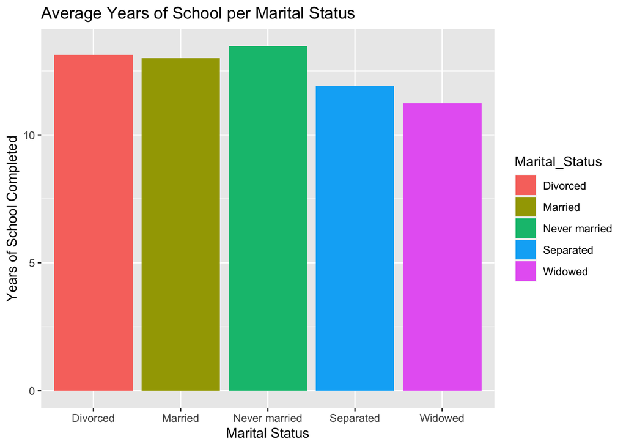

```r
#Finally Clean Data
#sch_yrs <- as.numeric(dat$School_Years)

MS_Years <- dat %>%
mutate(school_yrs = as.numeric(dat$School_Years)) %>%
group_by(Marital_Status) %>%
summarize(count = n(), avgYears = mean(school_yrs))

ggplot(MS_Years, aes(x=Marital_Status, weight=avgYears, fill=Marital_Status)) + geom_bar() + ggtitle("Average Years of School per Marital Status") + xlab("Marital Status") + ylab("Years of School Completed")
```

Noting the average charts, it appears that the Separated and Widowed recipients had the least Years of school completed on average. The higest consisted of the Never Married group, followed closely by Divorced and Married.

2.Create a single data frame containing records for the better educated respondents with each marital status. A “better educated” respondent is someone who has strictly more years of education than the average among those with the same marital status. Print the structure of the data frame.

Answer:

```r
#install.packages('readxl')
library(dplyr)
library(ggplot2)
dat <- readxl::read_xls('/Users/nathanmarquardt/Desktop/ds202_lab3/GSS.xls')
names(dat)
```

```
##  [1] "Gss year for this respondent"
##  [2] "General happiness"
##  [3] "Political party affiliation"
##  [4] "Total family income"
##  [5] "Respondents sex"
##  [6] "Highest year of school completed"
##  [7] "Spouse self-emp. or works for somebody"
##  [8] "No. of hrs spouse usually works a week"
##  [9] "Number of hrs spouse worked last week"
## [10] "Spouse labor force status"
## [11] "Ever been divorced or separated"
## [12] "Marital status"
## [13] "R self-emp or works for somebody"
## [14] "Number of hours usually work a week"
## [15] "Number of hours worked last week"
## [16] "Labor force status"
## [17] "Respondent id number"
## [18] "Ballot used for interview"
```

```r
dat <- rename(dat, Year = `Gss year for this respondent`)
dat <- rename(dat, Happiness = `General happiness`)
dat <- rename(dat, Politic_Party = `Political party affiliation`)
dat <- rename(dat, FamIncome = `Total family income` )
dat <- rename(dat, Sex = `Respondents sex`)
dat <- rename(dat, School_Years = `Highest year of school completed`)
dat <- rename(dat, Spouse_EmpType = `Spouse self-emp. or works for somebody`)
dat <- rename(dat, Spouse_AvgHours = `No. of hrs spouse usually works a week`)
dat <- rename(dat, Spouse_LWHours = `Number of hrs spouse worked last week`)
dat <- rename(dat, Spouse_LaborStatus = `Spouse labor force status`)
dat <- rename(dat, Div_Sep_Status = `Ever been divorced or separated`)
dat <- rename(dat, Marital_Status = `Marital status`)
dat <- rename(dat, R_EmpType = `R self-emp or works for somebody`)
dat <- rename(dat, R_AvgHours = `Number of hours usually work a week`)
dat <- rename(dat, R_LWHours = `Number of hours worked last week`)
dat <- rename(dat, R_LaborStatus = `Labor force status`)
dat <- rename(dat, R_ID = `Respondent id number`)
dat <- rename(dat, Ballot_Type = `Ballot used for interview`)

unique(dat$Year)
```

```
##  [1] 1972 1973 1974 1975 1976 1977 1978 1980 1982 1983 1984 1985 1986 1987 1988
## [16] 1989 1990 1991 1993 1994 1996 1998 2000 2002 2004 2006 2008 2010 2012 2014
## [31] 2016 2018   NA
```

```r
dat <- filter(dat, Year != "NA")

unique(dat$Happiness)
```

```
## [1] "Not too happy"  "Pretty happy"   "Very happy"     "No answer"
## [5] "Don't know"     "Not applicable"
```

```r
dat <- filter(dat, Happiness != "No answer")
dat <- filter(dat, Happiness != "Don't know")
dat <- filter(dat, Happiness != "Not applicable")

unique(dat$Politic_Party)
```

```
##  [1] "Ind,near dem"       "Not str democrat"   "Independent"
##  [4] "Strong democrat"    "Not str republican" "Ind,near rep"
##  [7] "Strong republican"  "Other party"        "No answer"
## [10] "Don't know"
```

```r
dat <- filter(dat, Politic_Party != "No answer")
dat <- filter(dat, Politic_Party != "Don't know")

unique(dat$FamIncome)
```

```
##  [1] "Not applicable" "$10000 - 14999" "$7000 to 7999"  "$4000 to 4999"
##  [5] "$1000 to 2999"  "$15000 - 19999" "$5000 to 5999"  "$20000 - 24999"
##  [9] "$3000 to 3999"  "Don't know"     "Lt $1000"       "$8000 to 9999"
## [13] "$25000 or more" "$6000 to 6999"  "Refused"        "No answer"
```

```r
dat <- filter(dat, FamIncome != "No answer")
dat <- filter(dat, FamIncome != "Not applicable")
dat <- filter(dat, FamIncome != "Don't know")
dat <- filter(dat, FamIncome != "Refused")

unique(dat$Sex)
```

```
## [1] "Male"   "Female"
```

```r
unique(dat$School_Years)
```

```
##  [1] "6"          "8"          "11"         "12"         "16"
##  [6] "7"          "14"         "13"         "4"          "10"
## [11] "15"         "18"         "9"          "19"         "17"
## [16] "20"         "3"          "No answer"  "0"          "5"
## [21] "1"          "2"          "Don't know"
```

```r
dat <- filter(dat, School_Years != "No answer")
dat <- filter(dat, School_Years != "Don't know")

unique(dat$Div_Sep_Status)
```

```
## [1] "No"             "Not applicable" "Yes"            "No answer"
## [5] "Don't know"
```

```r
dat <- filter(dat, Div_Sep_Status != "No answer")
#dat <- filter(dat, Div_Sep_Status != "Not applicable")
dat <- filter(dat, Div_Sep_Status != "Don't know")

unique(dat$Marital_Status)
```

```
## [1] "Married"       "Divorced"      "Never married" "Widowed"
## [5] "Separated"
```

```r
unique(dat$R_EmpType)
```

```
## [1] "Someone else"   "Not applicable" "Self-employed"  "No answer"
## [5] "Don't know"
```

```r
dat <- filter(dat, R_EmpType != "No answer")
#dat <- filter(dat, R_EmpType != "Not applicable")
dat <- filter(dat, R_EmpType != "Don't know")

unique(dat$R_AvgHours)
```

```
##  [1] "Not applicable" "40"             "55"             "15"
##  [5] "56"             "50"             "10"             "35"
##  [9] "No answer"      "70"             "30"             "48"
## [13] "20"             "5"              "25"             "37"
## [17] "60"             "32"             "52"             "45"
## [21] "Don't know"     "75"             "24"             "4"
## [25] "89"             "44"             "13"             "8"
## [29] "12"             "34"             "6"              "80"
## [33] "39"             "21"             "47"             "38"
## [37] "33"             "46"             "42"             "43"
## [41] "11"             "16"             "66"             "36"
## [45] "58"             "18"             "65"             "84"
## [49] "17"             "68"             "41"             "1"
## [53] "7"              "0"              "72"             "28"
## [57] "27"             "26"             "3"              "9"
```

```r
dat <- filter(dat, R_AvgHours != "No answer")
#dat <- filter(dat, R_AvgHours != "Not applicable")
dat <- filter(dat, R_AvgHours != "Don't know")

unique(dat$R_LWHours)
```

```
##  [1] "27"             "Not applicable" "40"             "52"
##  [5] "35"             "45"             "70"             "60"
##  [9] "42"             "23"             "55"             "50"
## [13] "6"              "37"             "36"             "Don't know"
## [17] "48"             "16"             "24"             "20"
## [21] "80"             "65"             "15"             "39"
## [25] "25"             "22"             "44"             "26"
## [29] "38"             "12"             "41"             "84"
## [33] "54"             "32"             "3"              "29"
## [37] "51"             "30"             "No answer"      "89"
## [41] "43"             "18"             "58"             "28"
## [45] "46"             "8"              "9"              "19"
## [49] "14"             "66"             "61"             "49"
## [53] "10"             "72"             "34"             "75"
## [57] "53"             "7"              "21"             "47"
## [61] "57"             "71"             "13"             "5"
## [65] "31"             "17"             "56"             "4"
## [69] "0"              "33"             "68"             "11"
## [73] "2"              "85"             "62"             "59"
## [77] "78"             "77"             "64"             "63"
## [81] "67"             "73"             "88"             "69"
## [85] "76"             "74"             "81"             "79"
## [89] "86"             "1"              "87"             "83"
## [93] "82"
```

```r
dat <- filter(dat, R_LWHours != "No answer")
#dat <- filter(dat, R_EmpType != "Not applicable")
dat <- filter(dat, R_LWHours != "Don't know")

unique(dat$R_LaborStatus)
```

```
## [1] "Working fulltime" "Keeping house"    "Retired"          "Working parttime"
## [5] "School"           "Temp not working" "Other"            "Unempl, laid off"
```

```r
unique(dat$Spouse_EmpType)
```

```
## [1] "Someone else"   "Self-employed"  "Not applicable" "No answer"
## [5] "Don't know"
```

```r
dat <- filter(dat, Spouse_EmpType != "No answer")
#dat <- filter(dat, Spouse_EmpType != "Not applicable")
dat <- filter(dat, Spouse_EmpType != "Don't know")

unique(dat$Spouse_AvgHours)
```

```
##  [1] "Not applicable" "73"             "20"             "Don't know"
##  [5] "40"             "48"             "50"             "No answer"
##  [9] "16"             "84"             "56"             "13"
## [13] "32"             "8"              "44"             "37"
## [17] "72"             "24"             "35"             "12"
## [21] "60"             "54"             "22"             "43"
## [25] "25"             "38"             "30"             "45"
## [29] "36"             "65"             "57"             "89"
## [33] "14"             "55"             "52"             "70"
## [37] "51"             "21"             "10"             "5"
## [41] "46"             "47"             "42"             "26"
## [45] "80"             "27"             "18"             "1"
## [49] "15"             "34"
```

```r
dat <- filter(dat, Spouse_AvgHours != "No answer")
#dat <- filter(dat, Spouse_AvgHours != "Not applicable")
dat <- filter(dat, Spouse_AvgHours != "Don't know")

unique(dat$Spouse_LWHours)
```

```
##  [1] "Not applicable" "40"             "37"             "51"
##  [5] "60"             "45"             "44"             "55"
##  [9] "80"             "65"             "50"             "75"
## [13] "16"             "36"             "15"             "62"
## [17] "20"             "70"             "63"             "48"
## [21] "72"             "19"             "30"             "56"
## [25] "22"             "38"             "84"             "18"
## [29] "24"             "52"             "57"             "32"
## [33] "35"             "58"             "43"             "25"
## [37] "12"             "3"              "42"             "4"
## [41] "8"              "5"              "10"             "66"
## [45] "28"             "89"             "39"             "No answer"
## [49] "33"             "59"             "11"             "Don't know"
## [53] "74"             "54"             "21"             "79"
## [57] "9"              "46"             "69"             "6"
## [61] "29"             "47"             "23"             "13"
## [65] "73"             "34"             "68"             "76"
## [69] "49"             "14"             "78"             "41"
## [73] "64"             "77"             "82"             "26"
## [77] "85"             "2"              "27"             "61"
## [81] "88"             "31"             "7"              "53"
## [85] "17"             "71"             "0"              "67"
## [89] "81"             "1"              "86"
```

```r
dat <- filter(dat, Spouse_LWHours != "No answer")
#dat <- filter(dat, Spouse_AvgHours != "Not applicable")
dat <- filter(dat, Spouse_LWHours != "Don't know")

unique(dat$Spouse_LaborStatus)
```

```
## [1] "Keeping house"    "Other"            "Working fulltime" "Not applicable"
## [5] "Temp not working" "School"           "Working parttime" "Retired"
## [9] "Unempl, laid off"
```

```r
#Finally Clean Data
#sch_yrs <- as.numeric(dat$School_Years)
dat <- mutate(dat, sch_yrs_num = as.numeric(School_Years))

abveAvgDivDat <- filter(dat, (Marital_Status == "Divorced" & sch_yrs_num > 13.12685))
abveAvgMarDat <- filter(dat, (Marital_Status == "Married" & sch_yrs_num > 12.99896))
abveAvgNvmDat <- filter(dat, (Marital_Status == "Never married" & sch_yrs_num > 13.47385))
abveAvgSepDat <- filter(dat, (Marital_Status == "Separated" & sch_yrs_num > 11.91914))
abveAvgWdwDat <- filter(dat, (Marital_Status == "Widowed" & sch_yrs_num > 11.23538))

abveAvgData <- rbind(abveAvgDivDat, abveAvgMarDat, abveAvgNvmDat, abveAvgSepDat, abveAvgWdwDat)

?str
str(abveAvgData)
```

```
## tibble [24,496 × 19] (S3: tbl_df/tbl/data.frame)
##  $ Year              : num [1:24496] 1973 1973 1973 1973 1973 ...
##  $ Happiness         : chr [1:24496] "Not too happy" "Pretty happy" "Pretty happy" "Pretty happy" ...
##  $ Politic_Party     : chr [1:24496] "Strong republican" "Ind,near rep" "Strong republican" "Not str democrat" ...
##  $ FamIncome         : chr [1:24496] "$8000 to 9999" "$25000 or more" "$5000 to 5999" "$7000 to 7999" ...
##  $ Sex               : chr [1:24496] "Female" "Male" "Male" "Male" ...
##  $ School_Years      : chr [1:24496] "15" "14" "17" "18" ...
##  $ Spouse_EmpType    : chr [1:24496] "Not applicable" "Not applicable" "Not applicable" "Not applicable" ...
##  $ Spouse_AvgHours   : chr [1:24496] "Not applicable" "Not applicable" "Not applicable" "Not applicable" ...
##  $ Spouse_LWHours    : chr [1:24496] "Not applicable" "Not applicable" "Not applicable" "Not applicable" ...
##  $ Spouse_LaborStatus: chr [1:24496] "Not applicable" "Not applicable" "Not applicable" "Not applicable" ...
##  $ Div_Sep_Status    : chr [1:24496] "Not applicable" "Not applicable" "Not applicable" "Not applicable" ...
##  $ Marital_Status    : chr [1:24496] "Divorced" "Divorced" "Divorced" "Divorced" ...
##  $ R_EmpType         : chr [1:24496] "Someone else" "Self-employed" "Self-employed" "Someone else" ...
##  $ R_AvgHours        : chr [1:24496] "Not applicable" "Not applicable" "Not applicable" "Not applicable" ...
##  $ R_LWHours         : chr [1:24496] "Not applicable" "80" "Not applicable" "89" ...
##  $ R_LaborStatus     : chr [1:24496] "School" "Working fulltime" "Retired" "Working fulltime" ...
##  $ R_ID              : num [1:24496] 56 84 131 710 778 ...
##  $ Ballot_Type       : chr [1:24496] "Not applicable" "Not applicable" "Not applicable" "Not applicable" ...
##  $ sch_yrs_num       : num [1:24496] 15 14 17 18 14 14 15 14 16 20 ...
```

**For each of the investigation below, create at least one nemerical summary and one appropriate visualization. Write a paragraph to describe your findings and the variables you used.**

3.How is the happiness of a respondent related to his/her marriage status? Define that a person is happy if the resonse to question is “Very happy” or “Pretty happy”.

Answer:

```r
#install.packages('readxl')
library(dplyr)
library(ggplot2)
dat <- readxl::read_xls('/Users/nathanmarquardt/Desktop/ds202_lab3/GSS.xls')
names(dat)
```

```
##  [1] "Gss year for this respondent"
##  [2] "General happiness"
##  [3] "Political party affiliation"
##  [4] "Total family income"
##  [5] "Respondents sex"
##  [6] "Highest year of school completed"
##  [7] "Spouse self-emp. or works for somebody"
##  [8] "No. of hrs spouse usually works a week"
##  [9] "Number of hrs spouse worked last week"
## [10] "Spouse labor force status"
## [11] "Ever been divorced or separated"
## [12] "Marital status"
## [13] "R self-emp or works for somebody"
## [14] "Number of hours usually work a week"
## [15] "Number of hours worked last week"
## [16] "Labor force status"
## [17] "Respondent id number"
## [18] "Ballot used for interview"
```

```r
dat <- rename(dat, Year = `Gss year for this respondent`)
dat <- rename(dat, Happiness = `General happiness`)
dat <- rename(dat, Politic_Party = `Political party affiliation`)
dat <- rename(dat, FamIncome = `Total family income` )
dat <- rename(dat, Sex = `Respondents sex`)
dat <- rename(dat, School_Years = `Highest year of school completed`)
dat <- rename(dat, Spouse_EmpType = `Spouse self-emp. or works for somebody`)
dat <- rename(dat, Spouse_AvgHours = `No. of hrs spouse usually works a week`)
dat <- rename(dat, Spouse_LWHours = `Number of hrs spouse worked last week`)
dat <- rename(dat, Spouse_LaborStatus = `Spouse labor force status`)
dat <- rename(dat, Div_Sep_Status = `Ever been divorced or separated`)
dat <- rename(dat, Marital_Status = `Marital status`)
dat <- rename(dat, R_EmpType = `R self-emp or works for somebody`)
dat <- rename(dat, R_AvgHours = `Number of hours usually work a week`)
dat <- rename(dat, R_LWHours = `Number of hours worked last week`)
dat <- rename(dat, R_LaborStatus = `Labor force status`)
dat <- rename(dat, R_ID = `Respondent id number`)
dat <- rename(dat, Ballot_Type = `Ballot used for interview`)

unique(dat$Year)
```

```
##  [1] 1972 1973 1974 1975 1976 1977 1978 1980 1982 1983 1984 1985 1986 1987 1988
## [16] 1989 1990 1991 1993 1994 1996 1998 2000 2002 2004 2006 2008 2010 2012 2014
## [31] 2016 2018   NA
```

```r
dat <- filter(dat, Year != "NA")

unique(dat$Happiness)
```

```
## [1] "Not too happy"  "Pretty happy"   "Very happy"     "No answer"
## [5] "Don't know"     "Not applicable"
```

```r
dat <- filter(dat, Happiness != "No answer")
dat <- filter(dat, Happiness != "Don't know")
dat <- filter(dat, Happiness != "Not applicable")

unique(dat$Politic_Party)
```

```
##  [1] "Ind,near dem"       "Not str democrat"   "Independent"
##  [4] "Strong democrat"    "Not str republican" "Ind,near rep"
##  [7] "Strong republican"  "Other party"        "No answer"
## [10] "Don't know"
```

```r
dat <- filter(dat, Politic_Party != "No answer")
dat <- filter(dat, Politic_Party != "Don't know")

unique(dat$FamIncome)
```

```
##  [1] "Not applicable" "$10000 - 14999" "$7000 to 7999"  "$4000 to 4999"
##  [5] "$1000 to 2999"  "$15000 - 19999" "$5000 to 5999"  "$20000 - 24999"
##  [9] "$3000 to 3999"  "Don't know"     "Lt $1000"       "$8000 to 9999"
## [13] "$25000 or more" "$6000 to 6999"  "Refused"        "No answer"
```

```r
dat <- filter(dat, FamIncome != "No answer")
dat <- filter(dat, FamIncome != "Not applicable")
dat <- filter(dat, FamIncome != "Don't know")
dat <- filter(dat, FamIncome != "Refused")

unique(dat$Sex)
```

```
## [1] "Male"   "Female"
```

```r
unique(dat$School_Years)
```

```
##  [1] "6"          "8"          "11"         "12"         "16"
##  [6] "7"          "14"         "13"         "4"          "10"
## [11] "15"         "18"         "9"          "19"         "17"
## [16] "20"         "3"          "No answer"  "0"          "5"
## [21] "1"          "2"          "Don't know"
```

```r
dat <- filter(dat, School_Years != "No answer")
dat <- filter(dat, School_Years != "Don't know")

unique(dat$Div_Sep_Status)
```

```
## [1] "No"             "Not applicable" "Yes"            "No answer"
## [5] "Don't know"
```

```r
dat <- filter(dat, Div_Sep_Status != "No answer")
#dat <- filter(dat, Div_Sep_Status != "Not applicable")
dat <- filter(dat, Div_Sep_Status != "Don't know")

unique(dat$Marital_Status)
```

```
## [1] "Married"       "Divorced"      "Never married" "Widowed"
## [5] "Separated"
```

```r
unique(dat$R_EmpType)
```

```
## [1] "Someone else"   "Not applicable" "Self-employed"  "No answer"
## [5] "Don't know"
```

```r
dat <- filter(dat, R_EmpType != "No answer")
#dat <- filter(dat, R_EmpType != "Not applicable")
dat <- filter(dat, R_EmpType != "Don't know")

unique(dat$R_AvgHours)
```

```
##  [1] "Not applicable" "40"             "55"             "15"
##  [5] "56"             "50"             "10"             "35"
##  [9] "No answer"      "70"             "30"             "48"
## [13] "20"             "5"              "25"             "37"
## [17] "60"             "32"             "52"             "45"
## [21] "Don't know"     "75"             "24"             "4"
## [25] "89"             "44"             "13"             "8"
## [29] "12"             "34"             "6"              "80"
## [33] "39"             "21"             "47"             "38"
## [37] "33"             "46"             "42"             "43"
## [41] "11"             "16"             "66"             "36"
## [45] "58"             "18"             "65"             "84"
## [49] "17"             "68"             "41"             "1"
## [53] "7"              "0"              "72"             "28"
## [57] "27"             "26"             "3"              "9"
```

```r
dat <- filter(dat, R_AvgHours != "No answer")
#dat <- filter(dat, R_AvgHours != "Not applicable")
dat <- filter(dat, R_AvgHours != "Don't know")

unique(dat$R_LWHours)
```

```
##  [1] "27"             "Not applicable" "40"             "52"
##  [5] "35"             "45"             "70"             "60"
##  [9] "42"             "23"             "55"             "50"
## [13] "6"              "37"             "36"             "Don't know"
## [17] "48"             "16"             "24"             "20"
## [21] "80"             "65"             "15"             "39"
## [25] "25"             "22"             "44"             "26"
## [29] "38"             "12"             "41"             "84"
## [33] "54"             "32"             "3"              "29"
## [37] "51"             "30"             "No answer"      "89"
## [41] "43"             "18"             "58"             "28"
## [45] "46"             "8"              "9"              "19"
## [49] "14"             "66"             "61"             "49"
## [53] "10"             "72"             "34"             "75"
## [57] "53"             "7"              "21"             "47"
## [61] "57"             "71"             "13"             "5"
## [65] "31"             "17"             "56"             "4"
## [69] "0"              "33"             "68"             "11"
## [73] "2"              "85"             "62"             "59"
## [77] "78"             "77"             "64"             "63"
## [81] "67"             "73"             "88"             "69"
## [85] "76"             "74"             "81"             "79"
## [89] "86"             "1"              "87"             "83"
## [93] "82"
```

```r
dat <- filter(dat, R_LWHours != "No answer")
#dat <- filter(dat, R_EmpType != "Not applicable")
dat <- filter(dat, R_LWHours != "Don't know")

unique(dat$R_LaborStatus)
```

```
## [1] "Working fulltime" "Keeping house"    "Retired"          "Working parttime"
## [5] "School"           "Temp not working" "Other"            "Unempl, laid off"
```

```r
unique(dat$Spouse_EmpType)
```

```
## [1] "Someone else"   "Self-employed"  "Not applicable" "No answer"
## [5] "Don't know"
```

```r
dat <- filter(dat, Spouse_EmpType != "No answer")
#dat <- filter(dat, Spouse_EmpType != "Not applicable")
dat <- filter(dat, Spouse_EmpType != "Don't know")

unique(dat$Spouse_AvgHours)
```

```
##  [1] "Not applicable" "73"             "20"             "Don't know"
##  [5] "40"             "48"             "50"             "No answer"
##  [9] "16"             "84"             "56"             "13"
## [13] "32"             "8"              "44"             "37"
## [17] "72"             "24"             "35"             "12"
## [21] "60"             "54"             "22"             "43"
## [25] "25"             "38"             "30"             "45"
## [29] "36"             "65"             "57"             "89"
## [33] "14"             "55"             "52"             "70"
## [37] "51"             "21"             "10"             "5"
## [41] "46"             "47"             "42"             "26"
## [45] "80"             "27"             "18"             "1"
## [49] "15"             "34"
```

```r
dat <- filter(dat, Spouse_AvgHours != "No answer")
#dat <- filter(dat, Spouse_AvgHours != "Not applicable")
dat <- filter(dat, Spouse_AvgHours != "Don't know")

unique(dat$Spouse_LWHours)
```

```
##  [1] "Not applicable" "40"             "37"             "51"
##  [5] "60"             "45"             "44"             "55"
##  [9] "80"             "65"             "50"             "75"
## [13] "16"             "36"             "15"             "62"
## [17] "20"             "70"             "63"             "48"
## [21] "72"             "19"             "30"             "56"
## [25] "22"             "38"             "84"             "18"
## [29] "24"             "52"             "57"             "32"
## [33] "35"             "58"             "43"             "25"
## [37] "12"             "3"              "42"             "4"
## [41] "8"              "5"              "10"             "66"
## [45] "28"             "89"             "39"             "No answer"
## [49] "33"             "59"             "11"             "Don't know"
## [53] "74"             "54"             "21"             "79"
## [57] "9"              "46"             "69"             "6"
## [61] "29"             "47"             "23"             "13"
## [65] "73"             "34"             "68"             "76"
## [69] "49"             "14"             "78"             "41"
## [73] "64"             "77"             "82"             "26"
## [77] "85"             "2"              "27"             "61"
## [81] "88"             "31"             "7"              "53"
## [85] "17"             "71"             "0"              "67"
## [89] "81"             "1"              "86"
```

```r
dat <- filter(dat, Spouse_LWHours != "No answer")
#dat <- filter(dat, Spouse_AvgHours != "Not applicable")
dat <- filter(dat, Spouse_LWHours != "Don't know")

unique(dat$Spouse_LaborStatus)
```

```
## [1] "Keeping house"    "Other"            "Working fulltime" "Not applicable"
## [5] "Temp not working" "School"           "Working parttime" "Retired"
## [9] "Unempl, laid off"
```

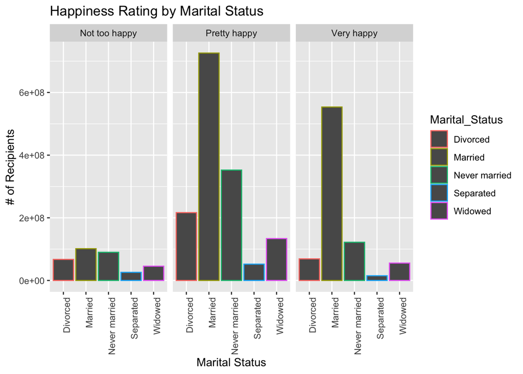

```r
#Finally Clean Data

ggplot(dat, aes(x=Marital_Status, weight=length(Marital_Status), color=Marital_Status)) + geom_bar() + theme(axis.text.x = element_text(angle = 90, hjust = 1)) + facet_wrap(~ Happiness) + ggtitle("Happiness Rating by Marital Status") + xlab("Marital Status") + ylab("# of Recipients")
```

```r
unique(dat$Marital_Status)
```

```
## [1] "Married"       "Divorced"      "Never married" "Widowed"
## [5] "Separated"
```

```r
marData <- filter(dat, Marital_Status == "Married")
divData <- filter(dat, Marital_Status == "Divorced")
nvmData <- filter(dat, Marital_Status == "Never married")
wdwData <- filter(dat, Marital_Status == "Widowed")
sepData <- filter(dat, Marital_Status == "Separated")

#Table for Married Data
table(marData$Happiness)
```

```
##
## Not too happy  Pretty happy    Very happy
##          1979         14165         10803
```

```r
#Table for Divorced Data
table(divData$Happiness)
```

```
##
## Not too happy  Pretty happy    Very happy
##          1311          4225          1346
```

```r
#Table for Never Married Data
table(nvmData$Happiness)
```

```
##
## Not too happy  Pretty happy    Very happy
##          1756          6876          2380
```

```r
#Table for Widowed Data
table(wdwData$Happiness)
```

```
##
## Not too happy  Pretty happy    Very happy
##           890          2610          1084
```

```r
#Table for Separated Data
table(sepData$Happiness)
```

```
##
## Not too happy  Pretty happy    Very happy
##           507          1017           294
```

Married individuals appear to have a much greater presence in the happy category. Based off of this data married individuals certainly are more likely to be happy than others. Marital status aside, the vast majority of respondents are happy. There does seem to be a pattern regardless of happiness, going from highest to lowest is married, never married, divorced, widowed, and separated. Based off of the tables we can see that the amount of people who are Pretty Happy always are much higher than very happy or not too happy. For most of the marital statuses very happy was only slightly different than not too happy, but since Pretty Happy and Very Happy are defined together as happy then it is clear from the tables that the majority of people are happy no matter what their marital status is.

4.Does party affiliation affect the relationship you found in the last question?

Answer:

```r
#install.packages('readxl')
library(dplyr)
library(ggplot2)
dat <- readxl::read_xls('/Users/nathanmarquardt/Desktop/ds202_lab3/GSS.xls')
names(dat)
```

```
##  [1] "Gss year for this respondent"
##  [2] "General happiness"
##  [3] "Political party affiliation"
##  [4] "Total family income"
##  [5] "Respondents sex"
##  [6] "Highest year of school completed"
##  [7] "Spouse self-emp. or works for somebody"
##  [8] "No. of hrs spouse usually works a week"
##  [9] "Number of hrs spouse worked last week"
## [10] "Spouse labor force status"
## [11] "Ever been divorced or separated"
## [12] "Marital status"
## [13] "R self-emp or works for somebody"
## [14] "Number of hours usually work a week"
## [15] "Number of hours worked last week"
## [16] "Labor force status"
## [17] "Respondent id number"
## [18] "Ballot used for interview"
```

```r
dat <- rename(dat, Year = `Gss year for this respondent`)
dat <- rename(dat, Happiness = `General happiness`)
dat <- rename(dat, Politic_Party = `Political party affiliation`)
dat <- rename(dat, FamIncome = `Total family income` )
dat <- rename(dat, Sex = `Respondents sex`)
dat <- rename(dat, School_Years = `Highest year of school completed`)
dat <- rename(dat, Spouse_EmpType = `Spouse self-emp. or works for somebody`)
dat <- rename(dat, Spouse_AvgHours = `No. of hrs spouse usually works a week`)
dat <- rename(dat, Spouse_LWHours = `Number of hrs spouse worked last week`)
dat <- rename(dat, Spouse_LaborStatus = `Spouse labor force status`)
dat <- rename(dat, Div_Sep_Status = `Ever been divorced or separated`)
dat <- rename(dat, Marital_Status = `Marital status`)
dat <- rename(dat, R_EmpType = `R self-emp or works for somebody`)
dat <- rename(dat, R_AvgHours = `Number of hours usually work a week`)
dat <- rename(dat, R_LWHours = `Number of hours worked last week`)
dat <- rename(dat, R_LaborStatus = `Labor force status`)
dat <- rename(dat, R_ID = `Respondent id number`)
dat <- rename(dat, Ballot_Type = `Ballot used for interview`)

unique(dat$Year)
```

```
##  [1] 1972 1973 1974 1975 1976 1977 1978 1980 1982 1983 1984 1985 1986 1987 1988
## [16] 1989 1990 1991 1993 1994 1996 1998 2000 2002 2004 2006 2008 2010 2012 2014
## [31] 2016 2018   NA
```

```r
dat <- filter(dat, Year != "NA")

unique(dat$Happiness)
```

```
## [1] "Not too happy"  "Pretty happy"   "Very happy"     "No answer"
## [5] "Don't know"     "Not applicable"
```

```r
dat <- filter(dat, Happiness != "No answer")
dat <- filter(dat, Happiness != "Don't know")
dat <- filter(dat, Happiness != "Not applicable")

unique(dat$Politic_Party)
```

```
##  [1] "Ind,near dem"       "Not str democrat"   "Independent"
##  [4] "Strong democrat"    "Not str republican" "Ind,near rep"
##  [7] "Strong republican"  "Other party"        "No answer"
## [10] "Don't know"
```

```r
dat <- filter(dat, Politic_Party != "No answer")
dat <- filter(dat, Politic_Party != "Don't know")

unique(dat$FamIncome)
```

```
##  [1] "Not applicable" "$10000 - 14999" "$7000 to 7999"  "$4000 to 4999"
##  [5] "$1000 to 2999"  "$15000 - 19999" "$5000 to 5999"  "$20000 - 24999"
##  [9] "$3000 to 3999"  "Don't know"     "Lt $1000"       "$8000 to 9999"
## [13] "$25000 or more" "$6000 to 6999"  "Refused"        "No answer"
```

```r
dat <- filter(dat, FamIncome != "No answer")
dat <- filter(dat, FamIncome != "Not applicable")
dat <- filter(dat, FamIncome != "Don't know")
dat <- filter(dat, FamIncome != "Refused")

unique(dat$Sex)
```

```
## [1] "Male"   "Female"
```

```r
unique(dat$School_Years)
```

```
##  [1] "6"          "8"          "11"         "12"         "16"
##  [6] "7"          "14"         "13"         "4"          "10"
## [11] "15"         "18"         "9"          "19"         "17"
## [16] "20"         "3"          "No answer"  "0"          "5"
## [21] "1"          "2"          "Don't know"
```

```r
dat <- filter(dat, School_Years != "No answer")
dat <- filter(dat, School_Years != "Don't know")

unique(dat$Div_Sep_Status)
```

```
## [1] "No"             "Not applicable" "Yes"            "No answer"
## [5] "Don't know"
```

```r
dat <- filter(dat, Div_Sep_Status != "No answer")
#dat <- filter(dat, Div_Sep_Status != "Not applicable")
dat <- filter(dat, Div_Sep_Status != "Don't know")

unique(dat$Marital_Status)
```

```
## [1] "Married"       "Divorced"      "Never married" "Widowed"
## [5] "Separated"
```

```r
unique(dat$R_EmpType)
```

```
## [1] "Someone else"   "Not applicable" "Self-employed"  "No answer"
## [5] "Don't know"
```

```r
dat <- filter(dat, R_EmpType != "No answer")
#dat <- filter(dat, R_EmpType != "Not applicable")
dat <- filter(dat, R_EmpType != "Don't know")

unique(dat$R_AvgHours)
```

```
##  [1] "Not applicable" "40"             "55"             "15"
##  [5] "56"             "50"             "10"             "35"
##  [9] "No answer"      "70"             "30"             "48"
## [13] "20"             "5"              "25"             "37"
## [17] "60"             "32"             "52"             "45"
## [21] "Don't know"     "75"             "24"             "4"
## [25] "89"             "44"             "13"             "8"
## [29] "12"             "34"             "6"              "80"
## [33] "39"             "21"             "47"             "38"
## [37] "33"             "46"             "42"             "43"
## [41] "11"             "16"             "66"             "36"
## [45] "58"             "18"             "65"             "84"
## [49] "17"             "68"             "41"             "1"
## [53] "7"              "0"              "72"             "28"
## [57] "27"             "26"             "3"              "9"
```

```r
dat <- filter(dat, R_AvgHours != "No answer")
#dat <- filter(dat, R_AvgHours != "Not applicable")
dat <- filter(dat, R_AvgHours != "Don't know")

unique(dat$R_LWHours)
```

```
##  [1] "27"             "Not applicable" "40"             "52"
##  [5] "35"             "45"             "70"             "60"
##  [9] "42"             "23"             "55"             "50"
## [13] "6"              "37"             "36"             "Don't know"
## [17] "48"             "16"             "24"             "20"
## [21] "80"             "65"             "15"             "39"
## [25] "25"             "22"             "44"             "26"
## [29] "38"             "12"             "41"             "84"
## [33] "54"             "32"             "3"              "29"
## [37] "51"             "30"             "No answer"      "89"
## [41] "43"             "18"             "58"             "28"
## [45] "46"             "8"              "9"              "19"
## [49] "14"             "66"             "61"             "49"
## [53] "10"             "72"             "34"             "75"
## [57] "53"             "7"              "21"             "47"
## [61] "57"             "71"             "13"             "5"
## [65] "31"             "17"             "56"             "4"
## [69] "0"              "33"             "68"             "11"
## [73] "2"              "85"             "62"             "59"
## [77] "78"             "77"             "64"             "63"
## [81] "67"             "73"             "88"             "69"
## [85] "76"             "74"             "81"             "79"
## [89] "86"             "1"              "87"             "83"
## [93] "82"
```

```r
dat <- filter(dat, R_LWHours != "No answer")
#dat <- filter(dat, R_EmpType != "Not applicable")
dat <- filter(dat, R_LWHours != "Don't know")

unique(dat$R_LaborStatus)
```

```
## [1] "Working fulltime" "Keeping house"    "Retired"          "Working parttime"
## [5] "School"           "Temp not working" "Other"            "Unempl, laid off"
```

```r
unique(dat$Spouse_EmpType)
```

```
## [1] "Someone else"   "Self-employed"  "Not applicable" "No answer"
## [5] "Don't know"
```

```r
dat <- filter(dat, Spouse_EmpType != "No answer")
#dat <- filter(dat, Spouse_EmpType != "Not applicable")
dat <- filter(dat, Spouse_EmpType != "Don't know")

unique(dat$Spouse_AvgHours)
```

```
##  [1] "Not applicable" "73"             "20"             "Don't know"
##  [5] "40"             "48"             "50"             "No answer"
##  [9] "16"             "84"             "56"             "13"
## [13] "32"             "8"              "44"             "37"
## [17] "72"             "24"             "35"             "12"
## [21] "60"             "54"             "22"             "43"
## [25] "25"             "38"             "30"             "45"
## [29] "36"             "65"             "57"             "89"
## [33] "14"             "55"             "52"             "70"
## [37] "51"             "21"             "10"             "5"
## [41] "46"             "47"             "42"             "26"
## [45] "80"             "27"             "18"             "1"
## [49] "15"             "34"
```

```r
dat <- filter(dat, Spouse_AvgHours != "No answer")
#dat <- filter(dat, Spouse_AvgHours != "Not applicable")
dat <- filter(dat, Spouse_AvgHours != "Don't know")

unique(dat$Spouse_LWHours)
```

```
##  [1] "Not applicable" "40"             "37"             "51"
##  [5] "60"             "45"             "44"             "55"
##  [9] "80"             "65"             "50"             "75"
## [13] "16"             "36"             "15"             "62"
## [17] "20"             "70"             "63"             "48"
## [21] "72"             "19"             "30"             "56"
## [25] "22"             "38"             "84"             "18"
## [29] "24"             "52"             "57"             "32"
## [33] "35"             "58"             "43"             "25"
## [37] "12"             "3"              "42"             "4"
## [41] "8"              "5"              "10"             "66"
## [45] "28"             "89"             "39"             "No answer"
## [49] "33"             "59"             "11"             "Don't know"
## [53] "74"             "54"             "21"             "79"
## [57] "9"              "46"             "69"             "6"
## [61] "29"             "47"             "23"             "13"
## [65] "73"             "34"             "68"             "76"
## [69] "49"             "14"             "78"             "41"
## [73] "64"             "77"             "82"             "26"
## [77] "85"             "2"              "27"             "61"
## [81] "88"             "31"             "7"              "53"
## [85] "17"             "71"             "0"              "67"
## [89] "81"             "1"              "86"
```

```r
dat <- filter(dat, Spouse_LWHours != "No answer")
#dat <- filter(dat, Spouse_AvgHours != "Not applicable")
dat <- filter(dat, Spouse_LWHours != "Don't know")

unique(dat$Spouse_LaborStatus)
```

```
## [1] "Keeping house"    "Other"            "Working fulltime" "Not applicable"
## [5] "Temp not working" "School"           "Working parttime" "Retired"
## [9] "Unempl, laid off"
```

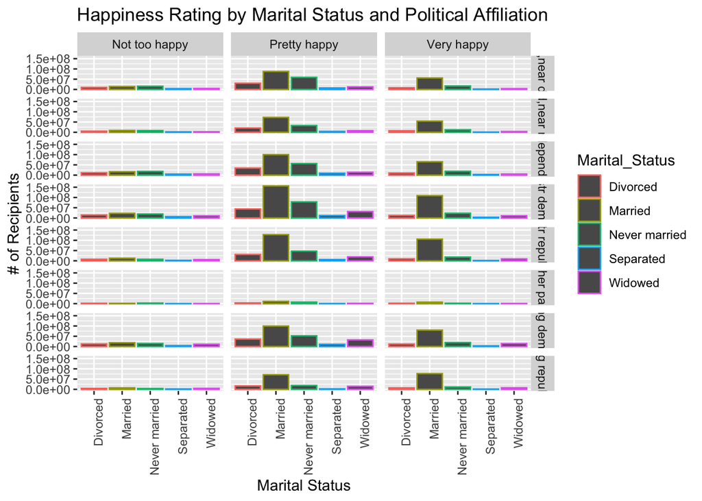

```r
#Finally Clean Data

ggplot(dat, aes(x=Marital_Status, weight=length(Marital_Status), color=Marital_Status)) + geom_bar() + theme(axis.text.x = element_text(angle = 90, hjust = 1)) + facet_grid(Politic_Party ~ Happiness) + ggtitle("Happiness Rating by Marital Status and Political Affiliation") + xlab("Marital Status") + ylab("# of Recipients")
```

```r
unique(dat$Marital_Status)
```

```
## [1] "Married"       "Divorced"      "Never married" "Widowed"
## [5] "Separated"
```

```r
marData <- filter(dat, Marital_Status == "Married")
divData <- filter(dat, Marital_Status == "Divorced")
nvmData <- filter(dat, Marital_Status == "Never married")
wdwData <- filter(dat, Marital_Status == "Widowed")
sepData <- filter(dat, Marital_Status == "Separated")

#Tables for Married Data
table(marData$Happiness)
```

```
##
## Not too happy  Pretty happy    Very happy
##          1979         14165         10803
```

```r
table(marData$Politic_Party)
```

```
##
##       Ind,near dem       Ind,near rep        Independent   Not str democrat
##               3079               2647               3545               5617
## Not str republican        Other party    Strong democrat  Strong republican
##               4796                380               3856               3027
```

```r
#Table for Divorced Data
table(divData$Happiness)
```

```
##
## Not too happy  Pretty happy    Very happy
##          1311          4225          1346
```

```r
table(divData$Politic_Party)
```

```
##
##       Ind,near dem       Ind,near rep        Independent   Not str democrat
##                938                652               1094               1385
## Not str republican        Other party    Strong democrat  Strong republican
##                942                139               1183                549
```

```r
#Table for Never Married Data
table(nvmData$Happiness)
```

```
##
## Not too happy  Pretty happy    Very happy
##          1756          6876          2380
```

```r
table(nvmData$Politic_Party)
```

```
##
##       Ind,near dem       Ind,near rep        Independent   Not str democrat
##               1781               1041               1829               2356
## Not str republican        Other party    Strong democrat  Strong republican
##               1424                231               1687                663
```

```r
#Table for Widowed Data
table(wdwData$Happiness)
```

```
##
## Not too happy  Pretty happy    Very happy
##           890          2610          1084
```

```r
table(wdwData$Politic_Party)
```

```
##
##       Ind,near dem       Ind,near rep        Independent   Not str democrat
##                407                270                493               1031
## Not str republican        Other party    Strong democrat  Strong republican
##                679                 50               1126                528
```

```r
#Table for Separated Data
table(sepData$Happiness)
```

```
##
## Not too happy  Pretty happy    Very happy
##           507          1017           294
```

```r
table(sepData$Politic_Party)
```

```
##
##       Ind,near dem       Ind,near rep        Independent   Not str democrat
##                251                135                338                424
## Not str republican        Other party    Strong democrat  Strong republican
##                187                 21                361                101
```

Judging from the facet grid, the happy people tend to hold the same pattern as the previous question, however there is a slight difference for the not too happy people. The never married indidviduals who are not too happy have a higher affinity towards the independent/ind near rep/ind near dem categories. Based off of the graph we can say that all people that are happy appear to be in abundance in not strong rep and not strong dem. According to the data tables, married, divorced, never married and separated people tend to be happy and not strong democrat. We noticed that the widowed individuals are happy and strong democrats.

5.How is marital status related to the education of a respondent? What are possible reasons accounting for the patterns you see?

Answer:

```r
#install.packages('readxl')
library(dplyr)
library(ggplot2)
dat <- readxl::read_xls('/Users/nathanmarquardt/Desktop/ds202_lab3/GSS.xls')
names(dat)
```

```
##  [1] "Gss year for this respondent"
##  [2] "General happiness"
##  [3] "Political party affiliation"
##  [4] "Total family income"
##  [5] "Respondents sex"
##  [6] "Highest year of school completed"
##  [7] "Spouse self-emp. or works for somebody"
##  [8] "No. of hrs spouse usually works a week"
##  [9] "Number of hrs spouse worked last week"
## [10] "Spouse labor force status"
## [11] "Ever been divorced or separated"
## [12] "Marital status"
## [13] "R self-emp or works for somebody"
## [14] "Number of hours usually work a week"
## [15] "Number of hours worked last week"
## [16] "Labor force status"
## [17] "Respondent id number"
## [18] "Ballot used for interview"
```

```r
dat <- rename(dat, Year = `Gss year for this respondent`)
dat <- rename(dat, Happiness = `General happiness`)
dat <- rename(dat, Politic_Party = `Political party affiliation`)
dat <- rename(dat, FamIncome = `Total family income` )
dat <- rename(dat, Sex = `Respondents sex`)
dat <- rename(dat, School_Years = `Highest year of school completed`)
dat <- rename(dat, Spouse_EmpType = `Spouse self-emp. or works for somebody`)
dat <- rename(dat, Spouse_AvgHours = `No. of hrs spouse usually works a week`)
dat <- rename(dat, Spouse_LWHours = `Number of hrs spouse worked last week`)
dat <- rename(dat, Spouse_LaborStatus = `Spouse labor force status`)
dat <- rename(dat, Div_Sep_Status = `Ever been divorced or separated`)
dat <- rename(dat, Marital_Status = `Marital status`)
dat <- rename(dat, R_EmpType = `R self-emp or works for somebody`)
dat <- rename(dat, R_AvgHours = `Number of hours usually work a week`)
dat <- rename(dat, R_LWHours = `Number of hours worked last week`)
dat <- rename(dat, R_LaborStatus = `Labor force status`)
dat <- rename(dat, R_ID = `Respondent id number`)
dat <- rename(dat, Ballot_Type = `Ballot used for interview`)

unique(dat$Year)
```

```
##  [1] 1972 1973 1974 1975 1976 1977 1978 1980 1982 1983 1984 1985 1986 1987 1988
## [16] 1989 1990 1991 1993 1994 1996 1998 2000 2002 2004 2006 2008 2010 2012 2014
## [31] 2016 2018   NA
```

```r
dat <- filter(dat, Year != "NA")

unique(dat$Happiness)
```

```
## [1] "Not too happy"  "Pretty happy"   "Very happy"     "No answer"
## [5] "Don't know"     "Not applicable"
```

```r
dat <- filter(dat, Happiness != "No answer")
dat <- filter(dat, Happiness != "Don't know")
dat <- filter(dat, Happiness != "Not applicable")

unique(dat$Politic_Party)
```

```
##  [1] "Ind,near dem"       "Not str democrat"   "Independent"
##  [4] "Strong democrat"    "Not str republican" "Ind,near rep"
##  [7] "Strong republican"  "Other party"        "No answer"
## [10] "Don't know"
```

```r
dat <- filter(dat, Politic_Party != "No answer")
dat <- filter(dat, Politic_Party != "Don't know")

unique(dat$FamIncome)
```

```
##  [1] "Not applicable" "$10000 - 14999" "$7000 to 7999"  "$4000 to 4999"
##  [5] "$1000 to 2999"  "$15000 - 19999" "$5000 to 5999"  "$20000 - 24999"
##  [9] "$3000 to 3999"  "Don't know"     "Lt $1000"       "$8000 to 9999"
## [13] "$25000 or more" "$6000 to 6999"  "Refused"        "No answer"
```

```r
dat <- filter(dat, FamIncome != "No answer")
dat <- filter(dat, FamIncome != "Not applicable")
dat <- filter(dat, FamIncome != "Don't know")
dat <- filter(dat, FamIncome != "Refused")

unique(dat$Sex)
```

```
## [1] "Male"   "Female"
```

```r
unique(dat$School_Years)
```

```
##  [1] "6"          "8"          "11"         "12"         "16"
##  [6] "7"          "14"         "13"         "4"          "10"
## [11] "15"         "18"         "9"          "19"         "17"
## [16] "20"         "3"          "No answer"  "0"          "5"
## [21] "1"          "2"          "Don't know"
```

```r
dat <- filter(dat, School_Years != "No answer")
dat <- filter(dat, School_Years != "Don't know")

unique(dat$Div_Sep_Status)
```

```
## [1] "No"             "Not applicable" "Yes"            "No answer"
## [5] "Don't know"
```

```r
dat <- filter(dat, Div_Sep_Status != "No answer")
#dat <- filter(dat, Div_Sep_Status != "Not applicable")
dat <- filter(dat, Div_Sep_Status != "Don't know")

unique(dat$Marital_Status)
```

```
## [1] "Married"       "Divorced"      "Never married" "Widowed"
## [5] "Separated"
```

```r
unique(dat$R_EmpType)
```

```
## [1] "Someone else"   "Not applicable" "Self-employed"  "No answer"
## [5] "Don't know"
```

```r
dat <- filter(dat, R_EmpType != "No answer")
#dat <- filter(dat, R_EmpType != "Not applicable")
dat <- filter(dat, R_EmpType != "Don't know")

unique(dat$R_AvgHours)
```

```
##  [1] "Not applicable" "40"             "55"             "15"
##  [5] "56"             "50"             "10"             "35"
##  [9] "No answer"      "70"             "30"             "48"
## [13] "20"             "5"              "25"             "37"
## [17] "60"             "32"             "52"             "45"
## [21] "Don't know"     "75"             "24"             "4"
## [25] "89"             "44"             "13"             "8"
## [29] "12"             "34"             "6"              "80"
## [33] "39"             "21"             "47"             "38"
## [37] "33"             "46"             "42"             "43"
## [41] "11"             "16"             "66"             "36"
## [45] "58"             "18"             "65"             "84"
## [49] "17"             "68"             "41"             "1"
## [53] "7"              "0"              "72"             "28"
## [57] "27"             "26"             "3"              "9"
```

```r
dat <- filter(dat, R_AvgHours != "No answer")
#dat <- filter(dat, R_AvgHours != "Not applicable")
dat <- filter(dat, R_AvgHours != "Don't know")

unique(dat$R_LWHours)
```

```
##  [1] "27"             "Not applicable" "40"             "52"
##  [5] "35"             "45"             "70"             "60"
##  [9] "42"             "23"             "55"             "50"
## [13] "6"              "37"             "36"             "Don't know"
## [17] "48"             "16"             "24"             "20"
## [21] "80"             "65"             "15"             "39"
## [25] "25"             "22"             "44"             "26"
## [29] "38"             "12"             "41"             "84"
## [33] "54"             "32"             "3"              "29"
## [37] "51"             "30"             "No answer"      "89"
## [41] "43"             "18"             "58"             "28"
## [45] "46"             "8"              "9"              "19"
## [49] "14"             "66"             "61"             "49"
## [53] "10"             "72"             "34"             "75"
## [57] "53"             "7"              "21"             "47"
## [61] "57"             "71"             "13"             "5"
## [65] "31"             "17"             "56"             "4"
## [69] "0"              "33"             "68"             "11"
## [73] "2"              "85"             "62"             "59"
## [77] "78"             "77"             "64"             "63"
## [81] "67"             "73"             "88"             "69"
## [85] "76"             "74"             "81"             "79"
## [89] "86"             "1"              "87"             "83"
## [93] "82"
```

```r
dat <- filter(dat, R_LWHours != "No answer")
#dat <- filter(dat, R_EmpType != "Not applicable")
dat <- filter(dat, R_LWHours != "Don't know")

unique(dat$R_LaborStatus)
```

```
## [1] "Working fulltime" "Keeping house"    "Retired"          "Working parttime"
## [5] "School"           "Temp not working" "Other"            "Unempl, laid off"
```

```r
unique(dat$Spouse_EmpType)
```

```
## [1] "Someone else"   "Self-employed"  "Not applicable" "No answer"
## [5] "Don't know"
```

```r
dat <- filter(dat, Spouse_EmpType != "No answer")
#dat <- filter(dat, Spouse_EmpType != "Not applicable")
dat <- filter(dat, Spouse_EmpType != "Don't know")

unique(dat$Spouse_AvgHours)
```

```
##  [1] "Not applicable" "73"             "20"             "Don't know"
##  [5] "40"             "48"             "50"             "No answer"
##  [9] "16"             "84"             "56"             "13"
## [13] "32"             "8"              "44"             "37"
## [17] "72"             "24"             "35"             "12"
## [21] "60"             "54"             "22"             "43"
## [25] "25"             "38"             "30"             "45"
## [29] "36"             "65"             "57"             "89"
## [33] "14"             "55"             "52"             "70"
## [37] "51"             "21"             "10"             "5"
## [41] "46"             "47"             "42"             "26"
## [45] "80"             "27"             "18"             "1"
## [49] "15"             "34"
```

```r
dat <- filter(dat, Spouse_AvgHours != "No answer")
#dat <- filter(dat, Spouse_AvgHours != "Not applicable")
dat <- filter(dat, Spouse_AvgHours != "Don't know")

unique(dat$Spouse_LWHours)
```

```
##  [1] "Not applicable" "40"             "37"             "51"
##  [5] "60"             "45"             "44"             "55"
##  [9] "80"             "65"             "50"             "75"
## [13] "16"             "36"             "15"             "62"
## [17] "20"             "70"             "63"             "48"
## [21] "72"             "19"             "30"             "56"
## [25] "22"             "38"             "84"             "18"
## [29] "24"             "52"             "57"             "32"
## [33] "35"             "58"             "43"             "25"
## [37] "12"             "3"              "42"             "4"
## [41] "8"              "5"              "10"             "66"
## [45] "28"             "89"             "39"             "No answer"
## [49] "33"             "59"             "11"             "Don't know"
## [53] "74"             "54"             "21"             "79"
## [57] "9"              "46"             "69"             "6"
## [61] "29"             "47"             "23"             "13"
## [65] "73"             "34"             "68"             "76"
## [69] "49"             "14"             "78"             "41"
## [73] "64"             "77"             "82"             "26"
## [77] "85"             "2"              "27"             "61"
## [81] "88"             "31"             "7"              "53"
## [85] "17"             "71"             "0"              "67"
## [89] "81"             "1"              "86"
```

```r
dat <- filter(dat, Spouse_LWHours != "No answer")
#dat <- filter(dat, Spouse_AvgHours != "Not applicable")
dat <- filter(dat, Spouse_LWHours != "Don't know")

unique(dat$Spouse_LaborStatus)
```

```
## [1] "Keeping house"    "Other"            "Working fulltime" "Not applicable"
## [5] "Temp not working" "School"           "Working parttime" "Retired"
## [9] "Unempl, laid off"
```

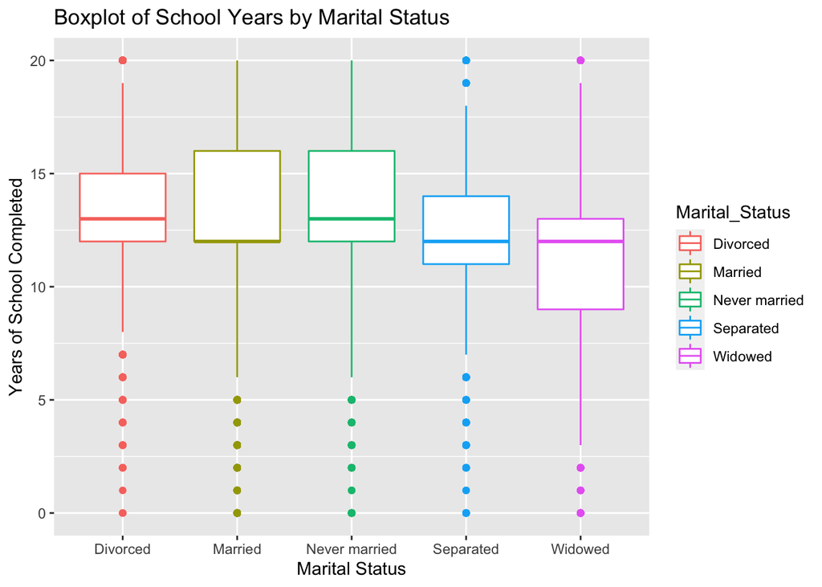

```r
#Finally Clean Data

ggplot(dat, aes(x=Marital_Status, y=as.numeric(School_Years), color=Marital_Status)) + geom_boxplot() + ggtitle("Boxplot of School Years by Marital Status") + xlab("Marital Status") + ylab("Years of School Completed")
```

```r
unique(dat$Marital_Status)
```

```
## [1] "Married"       "Divorced"      "Never married" "Widowed"
## [5] "Separated"
```

```r
marData <- filter(dat, Marital_Status == "Married")
divData <- filter(dat, Marital_Status == "Divorced")
nvmData <- filter(dat, Marital_Status == "Never married")
wdwData <- filter(dat, Marital_Status == "Widowed")
sepData <- filter(dat, Marital_Status == "Separated")

#Range for Married School Years
range(as.numeric(marData$School_Years))
```

```
## [1]  0 20
```

```r
#Range for Divorced School Years
range(as.numeric(divData$School_Years))
```

```
## [1]  0 20
```

```r
#Range for Never Married School Years
range(as.numeric(nvmData$School_Years))
```

```
## [1]  0 20
```

```r
#Range for Widowed School Years
range(as.numeric(wdwData$School_Years))
```

```
## [1]  0 20
```

```r
#Range for Separated School Years
range(as.numeric(sepData$School_Years))
```

```
## [1]  0 20
```

```r
MS_Years <- dat %>%
mutate(school_yrs = as.numeric(dat$School_Years)) %>%
group_by(Marital_Status) %>%
summarize(avgYears = mean(school_yrs))

MS_Years
```

```
## # A tibble: 5 x 2
##   Marital_Status avgYears
## * <chr>             <dbl>
## 1 Divorced           13.1
## 2 Married            13.0
## 3 Never married      13.5
## 4 Separated          11.9
## 5 Widowed            11.2
```

```r
unique(dat$R_LaborStatus)
```

```
## [1] "Working fulltime" "Keeping house"    "Retired"          "Working parttime"
## [5] "School"           "Temp not working" "Other"            "Unempl, laid off"
```

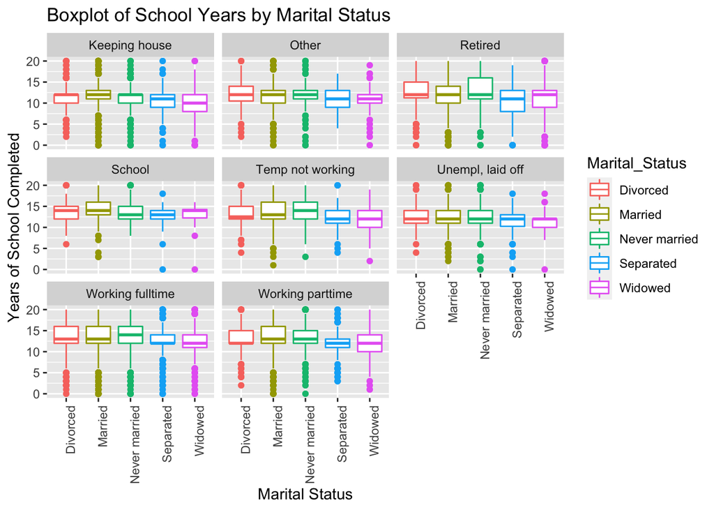

```r
ggplot(dat, aes(x=Marital_Status, y=as.numeric(School_Years), color=Marital_Status)) + geom_boxplot() + ggtitle("Boxplot of School Years by Marital Status") + xlab("Marital Status") + ylab("Years of School Completed") + facet_wrap(~R_LaborStatus) + theme(axis.text.x = element_text(angle = 90, hjust = 1))
```

6.Explore two more interesting questions, and answer those questions using the GSS data.

Answer:

1. Were recipients happier before 2000 or after 2000?

```r
#install.packages('readxl')
library(dplyr)
library(ggplot2)
dat <- readxl::read_xls('/Users/nathanmarquardt/Desktop/ds202_lab3/GSS.xls')
names(dat)
```

```
##  [1] "Gss year for this respondent"
##  [2] "General happiness"
##  [3] "Political party affiliation"
##  [4] "Total family income"
##  [5] "Respondents sex"
##  [6] "Highest year of school completed"
##  [7] "Spouse self-emp. or works for somebody"
##  [8] "No. of hrs spouse usually works a week"
##  [9] "Number of hrs spouse worked last week"
## [10] "Spouse labor force status"
## [11] "Ever been divorced or separated"
## [12] "Marital status"
## [13] "R self-emp or works for somebody"
## [14] "Number of hours usually work a week"
## [15] "Number of hours worked last week"
## [16] "Labor force status"
## [17] "Respondent id number"
## [18] "Ballot used for interview"
```

```r
dat <- rename(dat, Year = `Gss year for this respondent`)
dat <- rename(dat, Happiness = `General happiness`)
dat <- rename(dat, Politic_Party = `Political party affiliation`)
dat <- rename(dat, FamIncome = `Total family income` )
dat <- rename(dat, Sex = `Respondents sex`)
dat <- rename(dat, School_Years = `Highest year of school completed`)
dat <- rename(dat, Spouse_EmpType = `Spouse self-emp. or works for somebody`)
dat <- rename(dat, Spouse_AvgHours = `No. of hrs spouse usually works a week`)
dat <- rename(dat, Spouse_LWHours = `Number of hrs spouse worked last week`)
dat <- rename(dat, Spouse_LaborStatus = `Spouse labor force status`)
dat <- rename(dat, Div_Sep_Status = `Ever been divorced or separated`)
dat <- rename(dat, Marital_Status = `Marital status`)
dat <- rename(dat, R_EmpType = `R self-emp or works for somebody`)
dat <- rename(dat, R_AvgHours = `Number of hours usually work a week`)
dat <- rename(dat, R_LWHours = `Number of hours worked last week`)
dat <- rename(dat, R_LaborStatus = `Labor force status`)
dat <- rename(dat, R_ID = `Respondent id number`)
dat <- rename(dat, Ballot_Type = `Ballot used for interview`)

unique(dat$Year)
```

```
##  [1] 1972 1973 1974 1975 1976 1977 1978 1980 1982 1983 1984 1985 1986 1987 1988
## [16] 1989 1990 1991 1993 1994 1996 1998 2000 2002 2004 2006 2008 2010 2012 2014
## [31] 2016 2018   NA
```

```r
dat <- filter(dat, Year != "NA")

unique(dat$Happiness)
```

```
## [1] "Not too happy"  "Pretty happy"   "Very happy"     "No answer"
## [5] "Don't know"     "Not applicable"
```

```r
dat <- filter(dat, Happiness != "No answer")
dat <- filter(dat, Happiness != "Don't know")
dat <- filter(dat, Happiness != "Not applicable")

unique(dat$Politic_Party)
```

```
##  [1] "Ind,near dem"       "Not str democrat"   "Independent"
##  [4] "Strong democrat"    "Not str republican" "Ind,near rep"
##  [7] "Strong republican"  "Other party"        "No answer"
## [10] "Don't know"
```

```r
dat <- filter(dat, Politic_Party != "No answer")
dat <- filter(dat, Politic_Party != "Don't know")

unique(dat$FamIncome)
```

```
##  [1] "Not applicable" "$10000 - 14999" "$7000 to 7999"  "$4000 to 4999"
##  [5] "$1000 to 2999"  "$15000 - 19999" "$5000 to 5999"  "$20000 - 24999"
##  [9] "$3000 to 3999"  "Don't know"     "Lt $1000"       "$8000 to 9999"
## [13] "$25000 or more" "$6000 to 6999"  "Refused"        "No answer"
```

```r
dat <- filter(dat, FamIncome != "No answer")
dat <- filter(dat, FamIncome != "Not applicable")
dat <- filter(dat, FamIncome != "Don't know")
dat <- filter(dat, FamIncome != "Refused")

unique(dat$Sex)
```

```
## [1] "Male"   "Female"
```

```r
unique(dat$School_Years)
```

```
##  [1] "6"          "8"          "11"         "12"         "16"
##  [6] "7"          "14"         "13"         "4"          "10"
## [11] "15"         "18"         "9"          "19"         "17"
## [16] "20"         "3"          "No answer"  "0"          "5"
## [21] "1"          "2"          "Don't know"
```

```r
dat <- filter(dat, School_Years != "No answer")
dat <- filter(dat, School_Years != "Don't know")

unique(dat$Div_Sep_Status)
```

```
## [1] "No"             "Not applicable" "Yes"            "No answer"
## [5] "Don't know"
```

```r
dat <- filter(dat, Div_Sep_Status != "No answer")
#dat <- filter(dat, Div_Sep_Status != "Not applicable")
dat <- filter(dat, Div_Sep_Status != "Don't know")

unique(dat$Marital_Status)
```

```
## [1] "Married"       "Divorced"      "Never married" "Widowed"
## [5] "Separated"
```

```r
unique(dat$R_EmpType)
```

```
## [1] "Someone else"   "Not applicable" "Self-employed"  "No answer"
## [5] "Don't know"
```

```r
dat <- filter(dat, R_EmpType != "No answer")
#dat <- filter(dat, R_EmpType != "Not applicable")
dat <- filter(dat, R_EmpType != "Don't know")

unique(dat$R_AvgHours)
```

```
##  [1] "Not applicable" "40"             "55"             "15"
##  [5] "56"             "50"             "10"             "35"
##  [9] "No answer"      "70"             "30"             "48"
## [13] "20"             "5"              "25"             "37"
## [17] "60"             "32"             "52"             "45"
## [21] "Don't know"     "75"             "24"             "4"
## [25] "89"             "44"             "13"             "8"
## [29] "12"             "34"             "6"              "80"
## [33] "39"             "21"             "47"             "38"
## [37] "33"             "46"             "42"             "43"
## [41] "11"             "16"             "66"             "36"
## [45] "58"             "18"             "65"             "84"
## [49] "17"             "68"             "41"             "1"
## [53] "7"              "0"              "72"             "28"
## [57] "27"             "26"             "3"              "9"
```

```r
dat <- filter(dat, R_AvgHours != "No answer")
#dat <- filter(dat, R_AvgHours != "Not applicable")
dat <- filter(dat, R_AvgHours != "Don't know")

unique(dat$R_LWHours)
```

```
##  [1] "27"             "Not applicable" "40"             "52"
##  [5] "35"             "45"             "70"             "60"
##  [9] "42"             "23"             "55"             "50"
## [13] "6"              "37"             "36"             "Don't know"
## [17] "48"             "16"             "24"             "20"
## [21] "80"             "65"             "15"             "39"
## [25] "25"             "22"             "44"             "26"
## [29] "38"             "12"             "41"             "84"
## [33] "54"             "32"             "3"              "29"
## [37] "51"             "30"             "No answer"      "89"
## [41] "43"             "18"             "58"             "28"
## [45] "46"             "8"              "9"              "19"
## [49] "14"             "66"             "61"             "49"
## [53] "10"             "72"             "34"             "75"
## [57] "53"             "7"              "21"             "47"
## [61] "57"             "71"             "13"             "5"
## [65] "31"             "17"             "56"             "4"
## [69] "0"              "33"             "68"             "11"
## [73] "2"              "85"             "62"             "59"
## [77] "78"             "77"             "64"             "63"
## [81] "67"             "73"             "88"             "69"
## [85] "76"             "74"             "81"             "79"
## [89] "86"             "1"              "87"             "83"
## [93] "82"
```

```r
dat <- filter(dat, R_LWHours != "No answer")
#dat <- filter(dat, R_EmpType != "Not applicable")
dat <- filter(dat, R_LWHours != "Don't know")

unique(dat$R_LaborStatus)
```

```
## [1] "Working fulltime" "Keeping house"    "Retired"          "Working parttime"
## [5] "School"           "Temp not working" "Other"            "Unempl, laid off"
```

```r
unique(dat$Spouse_EmpType)
```

```
## [1] "Someone else"   "Self-employed"  "Not applicable" "No answer"
## [5] "Don't know"
```

```r
dat <- filter(dat, Spouse_EmpType != "No answer")
#dat <- filter(dat, Spouse_EmpType != "Not applicable")
dat <- filter(dat, Spouse_EmpType != "Don't know")

unique(dat$Spouse_AvgHours)
```

```
##  [1] "Not applicable" "73"             "20"             "Don't know"
##  [5] "40"             "48"             "50"             "No answer"
##  [9] "16"             "84"             "56"             "13"
## [13] "32"             "8"              "44"             "37"
## [17] "72"             "24"             "35"             "12"
## [21] "60"             "54"             "22"             "43"
## [25] "25"             "38"             "30"             "45"
## [29] "36"             "65"             "57"             "89"
## [33] "14"             "55"             "52"             "70"
## [37] "51"             "21"             "10"             "5"
## [41] "46"             "47"             "42"             "26"
## [45] "80"             "27"             "18"             "1"
## [49] "15"             "34"
```

```r
dat <- filter(dat, Spouse_AvgHours != "No answer")
#dat <- filter(dat, Spouse_AvgHours != "Not applicable")
dat <- filter(dat, Spouse_AvgHours != "Don't know")

unique(dat$Spouse_LWHours)
```

```
##  [1] "Not applicable" "40"             "37"             "51"
##  [5] "60"             "45"             "44"             "55"
##  [9] "80"             "65"             "50"             "75"
## [13] "16"             "36"             "15"             "62"
## [17] "20"             "70"             "63"             "48"
## [21] "72"             "19"             "30"             "56"
## [25] "22"             "38"             "84"             "18"
## [29] "24"             "52"             "57"             "32"
## [33] "35"             "58"             "43"             "25"
## [37] "12"             "3"              "42"             "4"
## [41] "8"              "5"              "10"             "66"
## [45] "28"             "89"             "39"             "No answer"
## [49] "33"             "59"             "11"             "Don't know"
## [53] "74"             "54"             "21"             "79"
## [57] "9"              "46"             "69"             "6"
## [61] "29"             "47"             "23"             "13"
## [65] "73"             "34"             "68"             "76"
## [69] "49"             "14"             "78"             "41"
## [73] "64"             "77"             "82"             "26"
## [77] "85"             "2"              "27"             "61"
## [81] "88"             "31"             "7"              "53"
## [85] "17"             "71"             "0"              "67"
## [89] "81"             "1"              "86"
```

```r
dat <- filter(dat, Spouse_LWHours != "No answer")
#dat <- filter(dat, Spouse_AvgHours != "Not applicable")
dat <- filter(dat, Spouse_LWHours != "Don't know")

unique(dat$Spouse_LaborStatus)
```

```
## [1] "Keeping house"    "Other"            "Working fulltime" "Not applicable"
## [5] "Temp not working" "School"           "Working parttime" "Retired"
## [9] "Unempl, laid off"
```

```r
#Finally Clean Data

unique(dat$Year)
```

```
##  [1] 1973 1974 1975 1976 1977 1978 1980 1982 1983 1984 1985 1986 1987 1988 1989
## [16] 1990 1991 1993 1994 1996 1998 2000 2002 2004 2006 2008 2010 2012 2014 2016
## [31] 2018
```

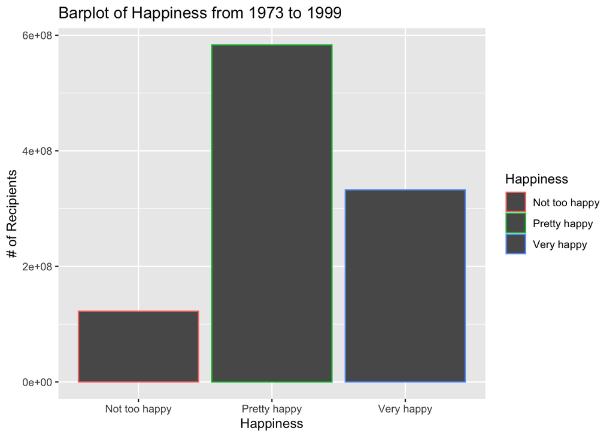

```r
dat1973 <- filter(dat, Year <= 1999)
dat2000 <- filter(dat, Year > 1999)
ggplot(dat1973, aes(x=Happiness, weight=length(Happiness), color=Happiness)) + geom_bar() + ggtitle("Barplot of Happiness from 1973 to 1999") + xlab("Happiness") + ylab("# of Recipients")
```

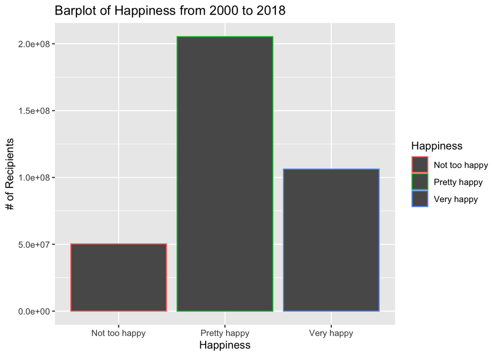

```r
ggplot(dat2000, aes(x=Happiness, weight=length(Happiness), color=Happiness)) + geom_bar() + ggtitle("Barplot of Happiness from 2000 to 2018") + xlab("Happiness") + ylab("# of Recipients")
```

```r
length(dat$Happiness)
```

```
## [1] 51243
```

```r
table(dat1973$Happiness)
```

```
##
## Not too happy  Pretty happy    Very happy
##          3798         18100         10321
```

```r
percNTH73 <- 3798 / 51243
percPH73 <- 18100 / 51243
percVH73 <- 10321 / 51243



table(dat2000$Happiness)
```

```
##
## Not too happy  Pretty happy    Very happy
##          2645         10793          5586
```

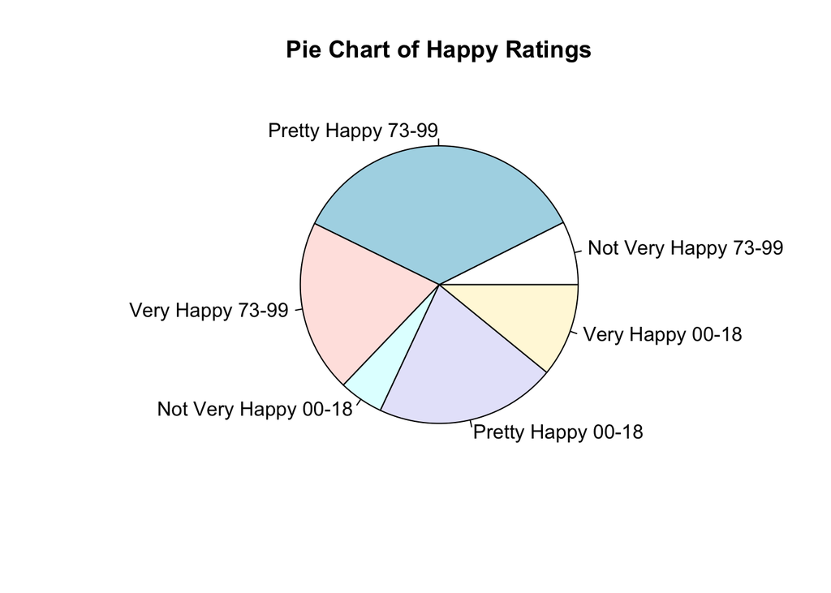

```r
percNTH00 <- 2645 / 51243
percPH00 <- 10793 / 51243
percVH00 <- 5586 / 51243

slices <- c(percNTH73, percPH73, percVH73, percNTH00, percPH00, percVH00)
lbls <- c("Not Very Happy 73-99", "Pretty Happy 73-99", "Very Happy 73-99", "Not Very Happy 00-18", "Pretty Happy 00-18", "Very Happy 00-18")

pie(slices, labels = lbls, main = "Pie Chart of Happy Ratings")
```

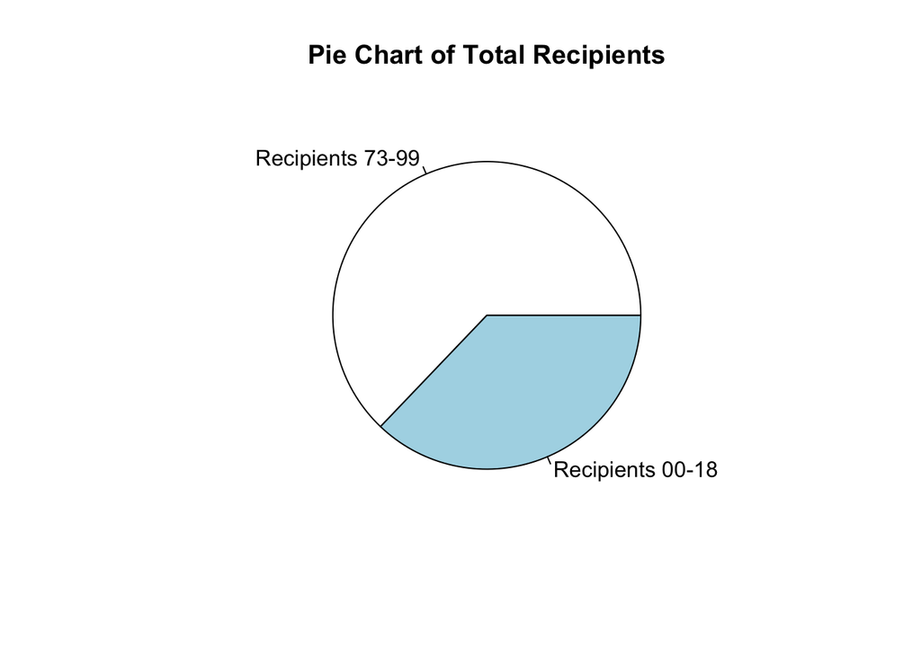

```r
numReps73 <- length(dat1973$Happiness)
numReps00 <- length(dat2000$Happiness)

percReps73 <- numReps73 / length(dat$Happiness)
percReps00 <- numReps00 / length(dat$Happiness)

slices2 <- c(percReps73, percReps00)
lbls2 <- c("Recipients 73-99", "Recipients 00-18")

pie(slices2, labels = lbls2, main = "Pie Chart of Total Recipients")
```

The barplots show that happiness exhibits the same distribution regardless of the time frame, Pretty Happy being the highest and Not Too Happy being the lowest. From our definition from question 3 we can conclude that the vast majority of people are happy no matter what time they were in. However based off of the pie charts we can see that the amount of recipients before 2000 is more than half of the total. The pie chart shows as well that Pretty Happy was the most populated category for both times.

2. Is Happiness impacted by the recipient’s type of employment?

```r
 # install.packages('readxl')
library(dplyr)
library(ggplot2)
dat <- readxl::read_xls('/Users/nathanmarquardt/Desktop/ds202_lab3/GSS.xls')
names(dat)
```

```
##  [1] "Gss year for this respondent"
##  [2] "General happiness"
##  [3] "Political party affiliation"
##  [4] "Total family income"
##  [5] "Respondents sex"
##  [6] "Highest year of school completed"
##  [7] "Spouse self-emp. or works for somebody"
##  [8] "No. of hrs spouse usually works a week"
##  [9] "Number of hrs spouse worked last week"
## [10] "Spouse labor force status"
## [11] "Ever been divorced or separated"
## [12] "Marital status"
## [13] "R self-emp or works for somebody"
## [14] "Number of hours usually work a week"
## [15] "Number of hours worked last week"
## [16] "Labor force status"
## [17] "Respondent id number"
## [18] "Ballot used for interview"
```

```r
dat <- rename(dat, Year = `Gss year for this respondent`)
dat <- rename(dat, Happiness = `General happiness`)
dat <- rename(dat, Politic_Party = `Political party affiliation`)
dat <- rename(dat, FamIncome = `Total family income` )
dat <- rename(dat, Sex = `Respondents sex`)
dat <- rename(dat, School_Years = `Highest year of school completed`)
dat <- rename(dat, Spouse_EmpType = `Spouse self-emp. or works for somebody`)
dat <- rename(dat, Spouse_AvgHours = `No. of hrs spouse usually works a week`)
dat <- rename(dat, Spouse_LWHours = `Number of hrs spouse worked last week`)
dat <- rename(dat, Spouse_LaborStatus = `Spouse labor force status`)
dat <- rename(dat, Div_Sep_Status = `Ever been divorced or separated`)
dat <- rename(dat, Marital_Status = `Marital status`)
dat <- rename(dat, R_EmpType = `R self-emp or works for somebody`)
dat <- rename(dat, R_AvgHours = `Number of hours usually work a week`)
dat <- rename(dat, R_LWHours = `Number of hours worked last week`)
dat <- rename(dat, R_LaborStatus = `Labor force status`)
dat <- rename(dat, R_ID = `Respondent id number`)
dat <- rename(dat, Ballot_Type = `Ballot used for interview`)

unique(dat$Year)
```

```
##  [1] 1972 1973 1974 1975 1976 1977 1978 1980 1982 1983 1984 1985 1986 1987 1988
## [16] 1989 1990 1991 1993 1994 1996 1998 2000 2002 2004 2006 2008 2010 2012 2014
## [31] 2016 2018   NA
```

```r
dat <- filter(dat, Year != "NA")

unique(dat$Happiness)
```

```
## [1] "Not too happy"  "Pretty happy"   "Very happy"     "No answer"
## [5] "Don't know"     "Not applicable"
```

```r
dat <- filter(dat, Happiness != "No answer")
dat <- filter(dat, Happiness != "Don't know")
dat <- filter(dat, Happiness != "Not applicable")

unique(dat$Politic_Party)
```

```
##  [1] "Ind,near dem"       "Not str democrat"   "Independent"
##  [4] "Strong democrat"    "Not str republican" "Ind,near rep"
##  [7] "Strong republican"  "Other party"        "No answer"
## [10] "Don't know"
```

```r
dat <- filter(dat, Politic_Party != "No answer")
dat <- filter(dat, Politic_Party != "Don't know")

unique(dat$FamIncome)
```

```
##  [1] "Not applicable" "$10000 - 14999" "$7000 to 7999"  "$4000 to 4999"
##  [5] "$1000 to 2999"  "$15000 - 19999" "$5000 to 5999"  "$20000 - 24999"
##  [9] "$3000 to 3999"  "Don't know"     "Lt $1000"       "$8000 to 9999"
## [13] "$25000 or more" "$6000 to 6999"  "Refused"        "No answer"
```

```r
dat <- filter(dat, FamIncome != "No answer")
dat <- filter(dat, FamIncome != "Not applicable")
dat <- filter(dat, FamIncome != "Don't know")
dat <- filter(dat, FamIncome != "Refused")

unique(dat$Sex)
```

```
## [1] "Male"   "Female"
```

```r
unique(dat$School_Years)
```

```
##  [1] "6"          "8"          "11"         "12"         "16"
##  [6] "7"          "14"         "13"         "4"          "10"
## [11] "15"         "18"         "9"          "19"         "17"
## [16] "20"         "3"          "No answer"  "0"          "5"
## [21] "1"          "2"          "Don't know"
```

```r
dat <- filter(dat, School_Years != "No answer")
dat <- filter(dat, School_Years != "Don't know")

unique(dat$Div_Sep_Status)
```

```
## [1] "No"             "Not applicable" "Yes"            "No answer"
## [5] "Don't know"
```

```r
dat <- filter(dat, Div_Sep_Status != "No answer")
#dat <- filter(dat, Div_Sep_Status != "Not applicable")
dat <- filter(dat, Div_Sep_Status != "Don't know")

unique(dat$Marital_Status)
```

```
## [1] "Married"       "Divorced"      "Never married" "Widowed"
## [5] "Separated"
```

```r
unique(dat$R_EmpType)
```

```
## [1] "Someone else"   "Not applicable" "Self-employed"  "No answer"
## [5] "Don't know"
```

```r
dat <- filter(dat, R_EmpType != "No answer")
#dat <- filter(dat, R_EmpType != "Not applicable")
dat <- filter(dat, R_EmpType != "Don't know")

unique(dat$R_AvgHours)
```

```
##  [1] "Not applicable" "40"             "55"             "15"
##  [5] "56"             "50"             "10"             "35"
##  [9] "No answer"      "70"             "30"             "48"
## [13] "20"             "5"              "25"             "37"
## [17] "60"             "32"             "52"             "45"
## [21] "Don't know"     "75"             "24"             "4"
## [25] "89"             "44"             "13"             "8"
## [29] "12"             "34"             "6"              "80"
## [33] "39"             "21"             "47"             "38"
## [37] "33"             "46"             "42"             "43"
## [41] "11"             "16"             "66"             "36"
## [45] "58"             "18"             "65"             "84"
## [49] "17"             "68"             "41"             "1"
## [53] "7"              "0"              "72"             "28"
## [57] "27"             "26"             "3"              "9"
```

```r
dat <- filter(dat, R_AvgHours != "No answer")
#dat <- filter(dat, R_AvgHours != "Not applicable")
dat <- filter(dat, R_AvgHours != "Don't know")

unique(dat$R_LWHours)
```

```
##  [1] "27"             "Not applicable" "40"             "52"
##  [5] "35"             "45"             "70"             "60"
##  [9] "42"             "23"             "55"             "50"
## [13] "6"              "37"             "36"             "Don't know"
## [17] "48"             "16"             "24"             "20"
## [21] "80"             "65"             "15"             "39"
## [25] "25"             "22"             "44"             "26"
## [29] "38"             "12"             "41"             "84"
## [33] "54"             "32"             "3"              "29"
## [37] "51"             "30"             "No answer"      "89"
## [41] "43"             "18"             "58"             "28"
## [45] "46"             "8"              "9"              "19"
## [49] "14"             "66"             "61"             "49"
## [53] "10"             "72"             "34"             "75"
## [57] "53"             "7"              "21"             "47"
## [61] "57"             "71"             "13"             "5"
## [65] "31"             "17"             "56"             "4"
## [69] "0"              "33"             "68"             "11"
## [73] "2"              "85"             "62"             "59"
## [77] "78"             "77"             "64"             "63"
## [81] "67"             "73"             "88"             "69"
## [85] "76"             "74"             "81"             "79"
## [89] "86"             "1"              "87"             "83"
## [93] "82"
```

```r
dat <- filter(dat, R_LWHours != "No answer")
#dat <- filter(dat, R_EmpType != "Not applicable")
dat <- filter(dat, R_LWHours != "Don't know")

unique(dat$R_LaborStatus)
```

```
## [1] "Working fulltime" "Keeping house"    "Retired"          "Working parttime"
## [5] "School"           "Temp not working" "Other"            "Unempl, laid off"
```

```r
unique(dat$Spouse_EmpType)
```

```
## [1] "Someone else"   "Self-employed"  "Not applicable" "No answer"
## [5] "Don't know"
```

```r
dat <- filter(dat, Spouse_EmpType != "No answer")
#dat <- filter(dat, Spouse_EmpType != "Not applicable")
dat <- filter(dat, Spouse_EmpType != "Don't know")

unique(dat$Spouse_AvgHours)
```

```
##  [1] "Not applicable" "73"             "20"             "Don't know"
##  [5] "40"             "48"             "50"             "No answer"
##  [9] "16"             "84"             "56"             "13"
## [13] "32"             "8"              "44"             "37"
## [17] "72"             "24"             "35"             "12"
## [21] "60"             "54"             "22"             "43"
## [25] "25"             "38"             "30"             "45"
## [29] "36"             "65"             "57"             "89"
## [33] "14"             "55"             "52"             "70"
## [37] "51"             "21"             "10"             "5"
## [41] "46"             "47"             "42"             "26"
## [45] "80"             "27"             "18"             "1"
## [49] "15"             "34"
```

```r
dat <- filter(dat, Spouse_AvgHours != "No answer")
#dat <- filter(dat, Spouse_AvgHours != "Not applicable")
dat <- filter(dat, Spouse_AvgHours != "Don't know")

unique(dat$Spouse_LWHours)
```

```
##  [1] "Not applicable" "40"             "37"             "51"
##  [5] "60"             "45"             "44"             "55"
##  [9] "80"             "65"             "50"             "75"
## [13] "16"             "36"             "15"             "62"
## [17] "20"             "70"             "63"             "48"
## [21] "72"             "19"             "30"             "56"
## [25] "22"             "38"             "84"             "18"
## [29] "24"             "52"             "57"             "32"
## [33] "35"             "58"             "43"             "25"
## [37] "12"             "3"              "42"             "4"
## [41] "8"              "5"              "10"             "66"
## [45] "28"             "89"             "39"             "No answer"
## [49] "33"             "59"             "11"             "Don't know"
## [53] "74"             "54"             "21"             "79"
## [57] "9"              "46"             "69"             "6"
## [61] "29"             "47"             "23"             "13"
## [65] "73"             "34"             "68"             "76"
## [69] "49"             "14"             "78"             "41"
## [73] "64"             "77"             "82"             "26"
## [77] "85"             "2"              "27"             "61"
## [81] "88"             "31"             "7"              "53"
## [85] "17"             "71"             "0"              "67"
## [89] "81"             "1"              "86"
```

```r
dat <- filter(dat, Spouse_LWHours != "No answer")
#dat <- filter(dat, Spouse_AvgHours != "Not applicable")
dat <- filter(dat, Spouse_LWHours != "Don't know")

unique(dat$Spouse_LaborStatus)
```

```
## [1] "Keeping house"    "Other"            "Working fulltime" "Not applicable"
## [5] "Temp not working" "School"           "Working parttime" "Retired"
## [9] "Unempl, laid off"
```

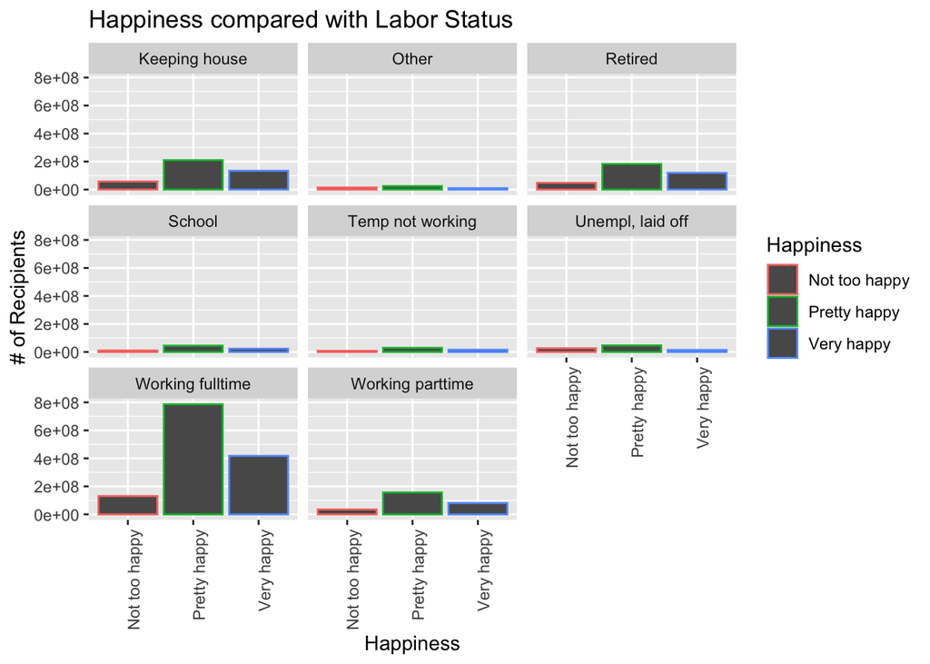

```r
#Finally Clean Data

ggplot(dat, aes(x=Happiness, weight=length(Happiness), color=Happiness)) + geom_bar() + facet_wrap(~R_LaborStatus) + ggtitle("Happiness compared with Labor Status") + xlab("Happiness") + ylab("# of Recipients") + theme(axis.text.x = element_text(angle = 90, hjust = 1))
```

```r
table(dat$R_LaborStatus)
```

```
##
##    Keeping house            Other          Retired           School
##             7836              955             6827             1530
## Temp not working Unempl, laid off Working fulltime Working parttime
##             1031             1701            26048             5315
```

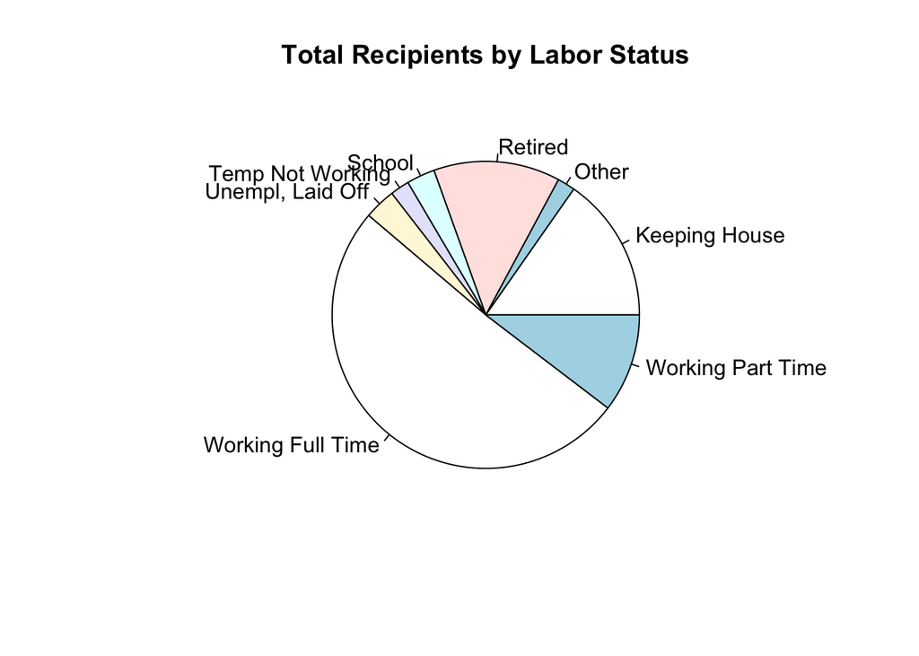

```r
percKH <- 7836 / length(dat$R_LaborStatus)
percOTH <- 955 / length(dat$R_LaborStatus)
percRET <- 6827 / length(dat$R_LaborStatus)
percSCH <- 1530 / length(dat$R_LaborStatus)
percTNW <- 1031 / length(dat$R_LaborStatus)
percULOW <- 1701 / length(dat$R_LaborStatus)
percWFT <- 26048 / length(dat$R_LaborStatus)
percWPT <- 5315 / length(dat$R_LaborStatus)

slices3 <- c(percKH, percOTH, percRET, percSCH, percTNW, percULOW, percWFT, percWPT)
lbls3 <- c("Keeping House", "Other", "Retired", "School", "Temp Not Working", "Unempl, Laid Off", "Working Full Time", "Working Part Time")

pie(slices3, labels = lbls3, main = "Total Recipients by Labor Status")
```

Based off of the facet bar graphs, we can conclude that as long as people were doing some kind of work, they were significantly more happy than not happy. Respondents in Other, School, Temp, and Unemployed showed little difference between happy and not happy. Working Full Time comprised of 50% of the population, which explains why the majority of people were happy.